# *Escherichia coli* Fitness Analyses

220 *Escherichia coli* lines underwent 36 days of mutation accumulation (MA), the time it takes to accumulate one mutation on average. The aim of the study was to estimate the distribution of fitness effects of new mutations (DFE) by measuring the growth rate of 188 of these MA lines and their common ancestor. Since the protocol also generated many lines that had accumulated no mutants, we could also estimate the distribution of fitness effects across genetically identical MA lines. We refer to this as the distribution of fitness effects due to environmental effects (EDFE) although acknowledge that we use the word ‘environmental’ to capture all systematic differences between lines not due to identified DNA mutations.

# 1 Data

The 188 *Escherichia coli* mutation accumulation lines and four ancestral replicate lines were split into two sets, each containing 94 MA lines and 2 replicates of the ancestral line. For each set, the frozen lines (`line`) were thawed and then grown while shaking for 16 hours at 37$^{\circ}$C in 10ml LB media, after which 10$\mu$L of culture was transferred to a 96-well filled with 180$\mu$L of LB. Optical density measurements (`OD`) were taken every 5 minutes for four hours (`timepoint` in hours). This was repeated 14 times, and the membership of each set and the position of each line (`row` and `column`) on the `plate` was randomised between replicates. The `date` on which the lines were defrosted and grown is recorded together with the `person` (JDH or DN) inoculating the cultures. JGS was responsible for inoculating all 96 well plates.

```r
library(dplyr)
library(gcplyr)
library(ggplot2)
library(tidyr)

od_df<-read.csv(file.path(root, "meta/growth_data.csv"))
```

We can plot the optical density (OD) over time (with time jittered):

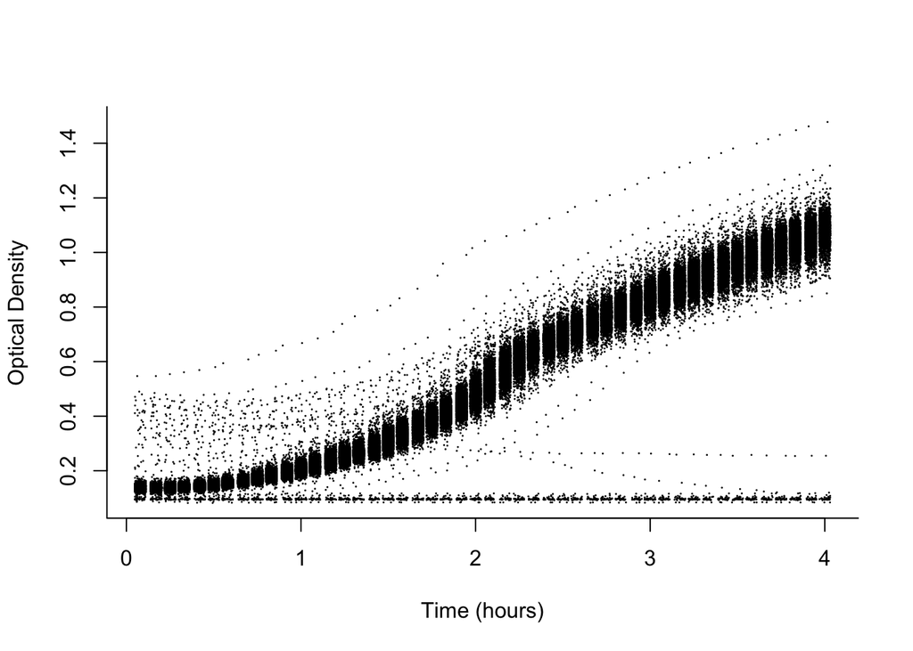

```r
plot(OD~jitter(timepoint,2), data=od_df, pch=16, cex=0.2, bty="l", ylab="Optical Density", xlab="Time (hours)")
```

While the bulk of the growth curves look reasonable, there are clearly some issues with no growth in some wells and some unusually high starting OD’s.

# 2 Data filtering

## 2.1 High starting OD

There are 38 replicates that have a starting OD higher than 0.2.

```r
od_df <- mutate(group_by(od_df, plate, row, column), startOD = OD[timepoint==0.08])
od_df$highOD<-od_df$startOD>0.2
tapply(od_df$highOD, od_df$plate, sum)/48
```

```
##  1  2  3  4  5  6  7  8  9 10 11 12 13 14 15 16 17 18 19 20 21 22 23 24 25 26
##  1  1  0  0  1  0  1  0  0  0  0  0  0  0  0  0  0  0  0  0  0 16 15  0  0  0
## 27 28
##  0  3
```

31 of these replicates were on plates 22 and 23. The function `plot_plate` allows us to visualise data in plate layout:

```r
plot_plate <- function(df, z, palette = "plasma", digits = 2) {

  ggplot(df, aes(x = as.factor(column), y = factor(row, levels=rev(LETTERS[1:8])), fill = df[[z]])) +
    geom_tile(colour = "grey50") +
    geom_text(aes(label = round(df[[z]], digits)),
              size = 3, colour = "white") +
    scale_fill_viridis_c(option = palette, na.value = "white") +
    coord_equal() +
    labs(x = "Column", y = "Row", fill = z) +
    theme_minimal(base_size = 14) +
    theme(panel.grid = element_blank())
}
```

We can see that wells with unusually high starting OD are clustered on the two plates:

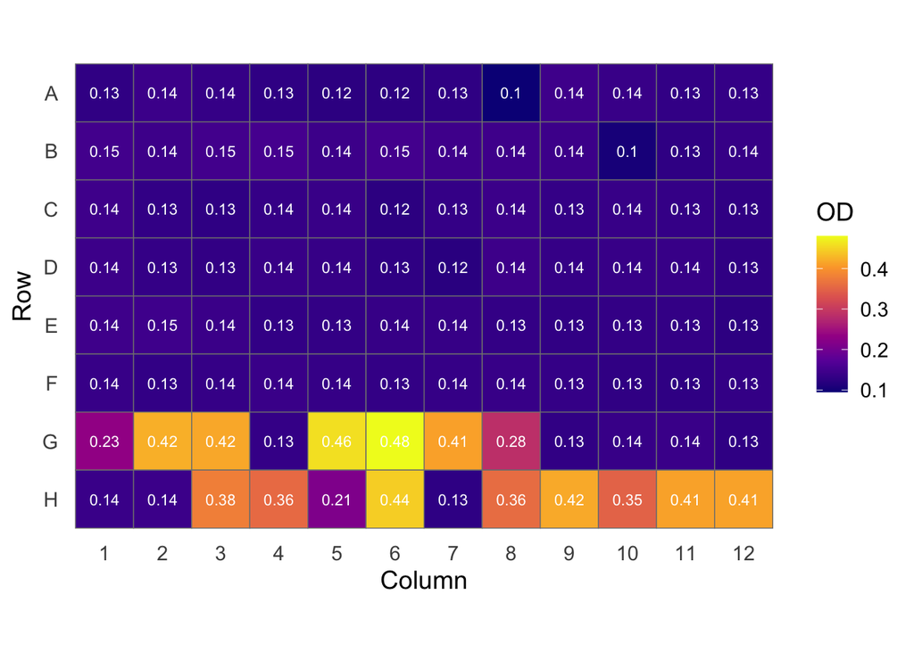

```r
plot_plate(subset(od_df, timepoint==0.08 & plate==22), z = "OD")
```

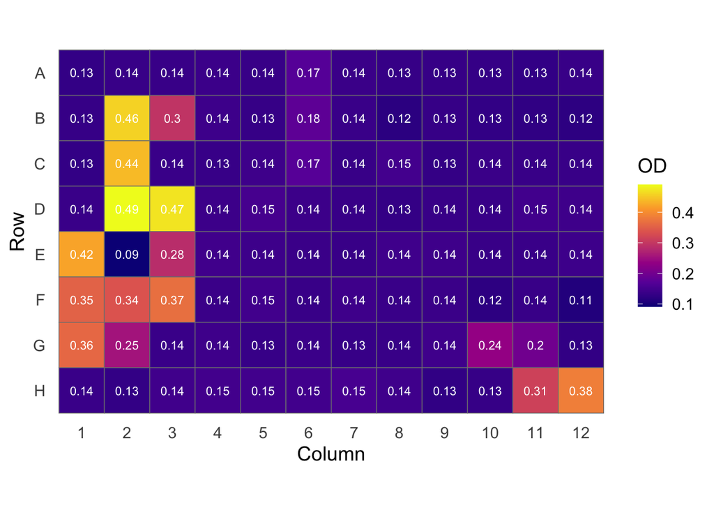

```r
plot_plate(subset(od_df, timepoint==0.08 & plate==23), z = "OD")
```

This does not look like systematic pipetting error, but rather some local issue with the plates. Of the remaining seven wells with high starting OD, two were known to be due to pipetting error and were doubly inoculated (5-H-1 and 28-G-1 in red) and two were unintentionally blacked-out (2-A-8 and 1-A-5 in blue, see below)

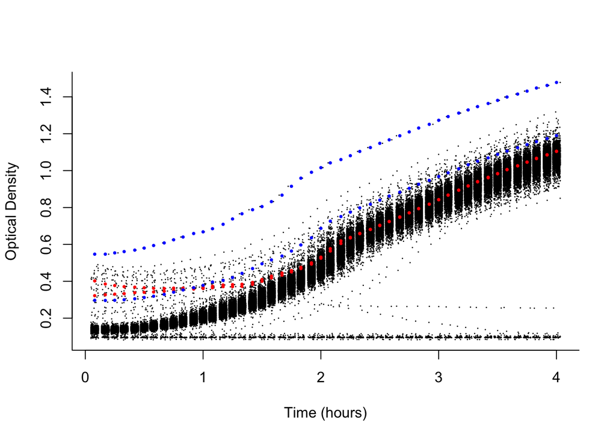

```r
plot(OD~jitter(timepoint,2), data=od_df, pch=16, cex=0.2, bty="l", ylab="Optical Density", xlab="Time (hours)")
points(OD~timepoint, data=subset(od_df, plate==5 & row=="H" & column==1), pch=16, cex=0.5, col="red")
points(OD~timepoint, data=subset(od_df, plate==28 & row=="G" & column==1), pch=16, cex=0.5, col="red")
points(OD~timepoint, data=subset(od_df, plate==2 & row=="A" & column==8), pch=16, cex=0.5, col="blue")
points(OD~timepoint, data=subset(od_df, plate==1 & row=="A" & column==5), pch=16, cex=0.5, col="blue")
```

For the remaining three wells (7-B-6, 28-B-4, 28-F-7) the starting OD was only a little above 0.2 and the growth curves look fine:

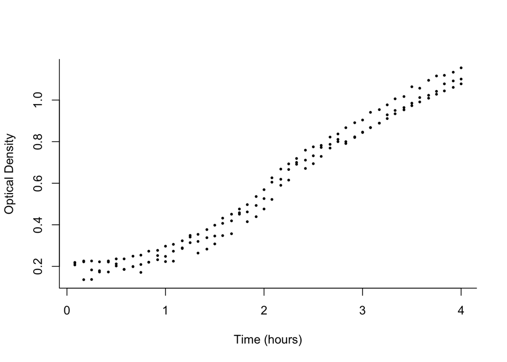

```r
plot(OD~timepoint, data=subset(od_df, highOD & plate%in%c(7,28) & row!="G"), pch=16, cex=0.5, bty="l", ylab="Optical Density", xlab="Time (hours)")
```

In order to retain these growth curves for later we will change their highOD flag to FALSE:

```r
with(od_df, highOD[which(highOD & plate%in%c(7,28) & row!="G")]<-FALSE)
```

## 2.2 Empty wells

In 40 cases the initial culture looked like it hadn’t grown, and in an error of judgement the culture was not assayed for growth and the well was either blacked-out (2-A-8 and 1-A-5, see above) or left empty (otherwise).

```r
plate.blank<-c(1, 2, 3, 5, 7, 9, 11, 11, 11, 15, 15, 15, 17, 19, 19, 21, 21, 21, 23, 23, 23, 25, 25, 27, 2, 8, 12, 18, 20, 22, 22, 22, 24, 24, 26, 28, 28, 28, 10, 10)
row.blank<-c("A", "A", "A", "B", "D", "H", "B", "D", "F", "F", "G", "H", "G", "B", "C", "A", "E", "F", "E", "F", "F", "C", "C", "D", "A", "C", "B", "F", "H", "A", "B", "H", "G", "F", "F", "C", "A", "E", "D", "H")
column.blank<-c(5, 8, 6, 3, 10, 5, 2, 3, 7, 6, 6, 12, 7, 12, 12, 6, 7, 8, 2, 2, 12, 2, 8, 2, 8, 12, 8, 4, 5, 8, 10, 10, 1, 1, 1, 2, 9, 9, 8, 12)
```

```r
od_df <- mutate(group_by(od_df, plate, row, column), empty = paste(plate, row, column)%in%paste(plate.blank, row.blank, column.blank))
```

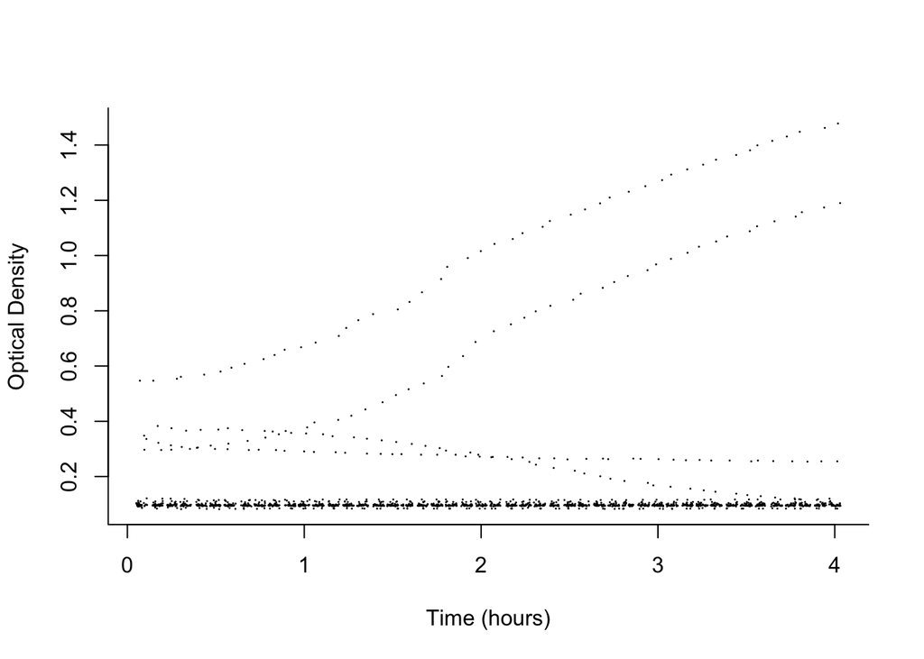

Note that four (rather than two) wells do not appear empty - the additional wells are 22-H-10 and 23-F-2 for which there appeared to be an issue with the plate (see above). The number of empty wells per line is clearly overdispersed:

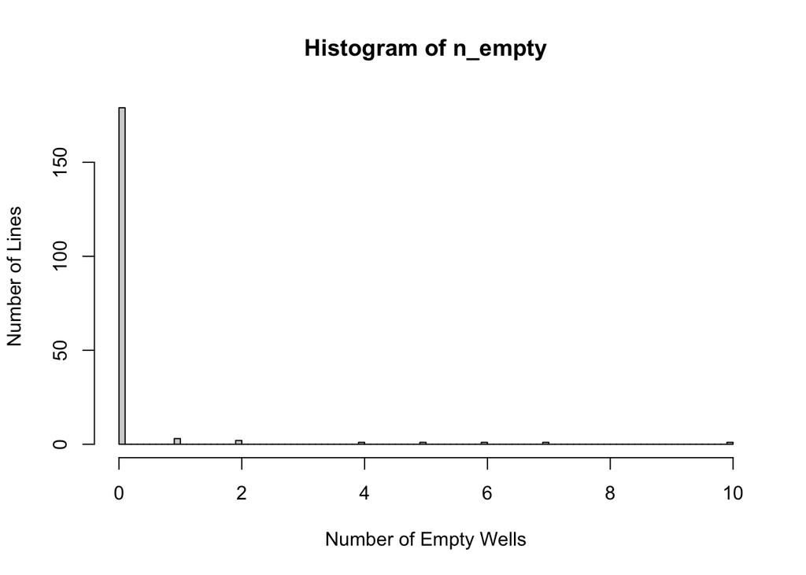

```r
n_empty<-tapply(od_df$empty, od_df$line, sum)/48
hist(n_empty, breaks=100, ylab="Number of Lines", xlab="Number of Empty Wells")
```

In particular line 180 repeatedly failed to grow (10 times out of 14).

```r
n_empty[which(n_empty!=0)]
```

```
## 118  16 180 203  29  43  68  81  84  97
##   5   6  10   1   1   4   2   7   2   1
```

## 2.3 Extra wells

In addition, well 5-F-9 also appears empty. This replicate was of line 180 which repeatedly failed to grow (see above).

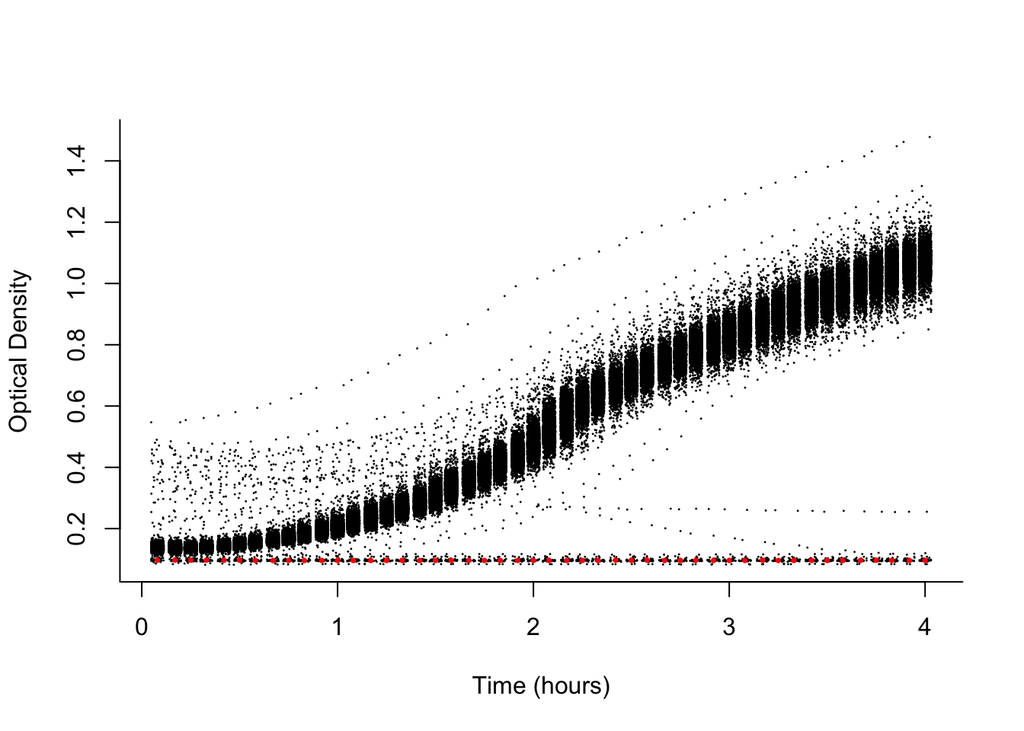

```r
od_df <- mutate(group_by(od_df, plate, row, column), extra_empty = OD[timepoint==2]<0.2 & !empty)
plot(OD~jitter(timepoint,2), data=od_df, pch=16, cex=0.2, bty="l", ylab="Optical Density", xlab="Time (hours)")
points(OD~timepoint, data=subset(od_df, extra_empty), pch=16, cex=0.5, col="red")
```

Nevertheless, three replicates of line 180 did grow despite starting at a low OD:

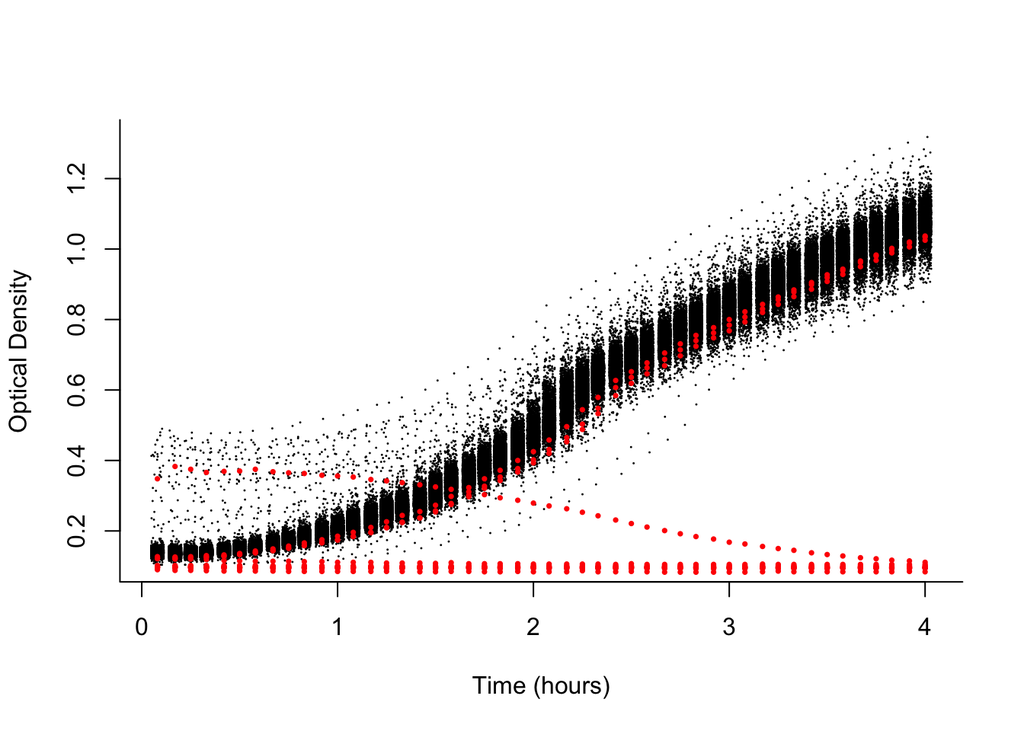

```r
plot(OD~jitter(timepoint,2),data=subset(od_df, !empty & !extra_empty), pch=16, cex=0.2, bty="l", ylab="Optical Density", xlab="Time (hours)")
points(OD~timepoint, data=subset(od_df, line=="180"), pch=16, cex=0.5, col="red")
```

## 2.4 Filtering

In what follows we remove empty wells and those in which the starting OD was greater than 0.2 (except 7-B-6, 28-B-4 and 28-F-7 which look fine):

```r
od_df <- subset(od_df, !highOD & !empty & !extra_empty)
```

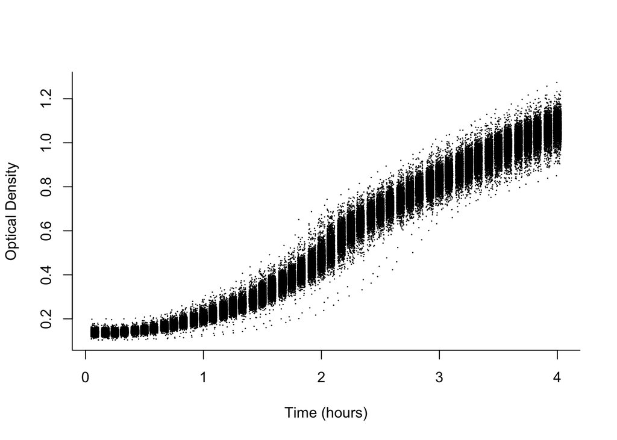

```r
plot(OD~jitter(timepoint,2),data=od_df, pch=16, cex=0.2, bty="l", ylab="Optical Density", xlab="Time (hours)")
```

# 3 Growth rate and meta data

In order to get an estimate of the growth rate in the exponential phase we can use gcplyr (Blazanin 2024). The change in log OD is computed over consecutive time-points for each well and a rolling 3-timepoint average calculated:

```r
df <- mutate(group_by(od_df, plate, row, column), deriv = calc_deriv(x = timepoint, y = OD, percapita = TRUE, blank = 0, window_width_n = 3, trans_y = 'log'))
```

For each well, the maximum average change is taken as the growth rate (`r`) and we can also obtain the OD at the time the maximum growth rate is achieved (`midOD`):

```r
df <- summarize(df, r = max_gc(deriv),  midOD=OD[which.max(deriv)], across(-c(timepoint, OD, deriv),first))
```

Since growth rates may be different in the inner wells, we can create a factor for modelling this

```r
df <- mutate(df, inner = as.numeric(!(row %in% c('A', 'H') | column %in% c(1, 12))))
```

`scripts/Mutation_Calling.Rmd` details the pipeline in which mutations were identified, and the number of mutations per line can be added:

```r
mutations<-read.csv(file.path(root, "meta/real_mutations.csv"))
```

```r
nmutations<-table(factor(mutations$line, levels=unique(df$line)))
df$n<-as.numeric(nmutations[df$line])
```

and have two indicator variables for whether a line is the ancestor (`anc`) or not (`noanc`):

```r
df$anc<-as.numeric(df$line=="anc")
df$noanc<-as.numeric(df$line!="anc")
```

A violin plot of the growth rates reveals an outlier with a very high growth rate:

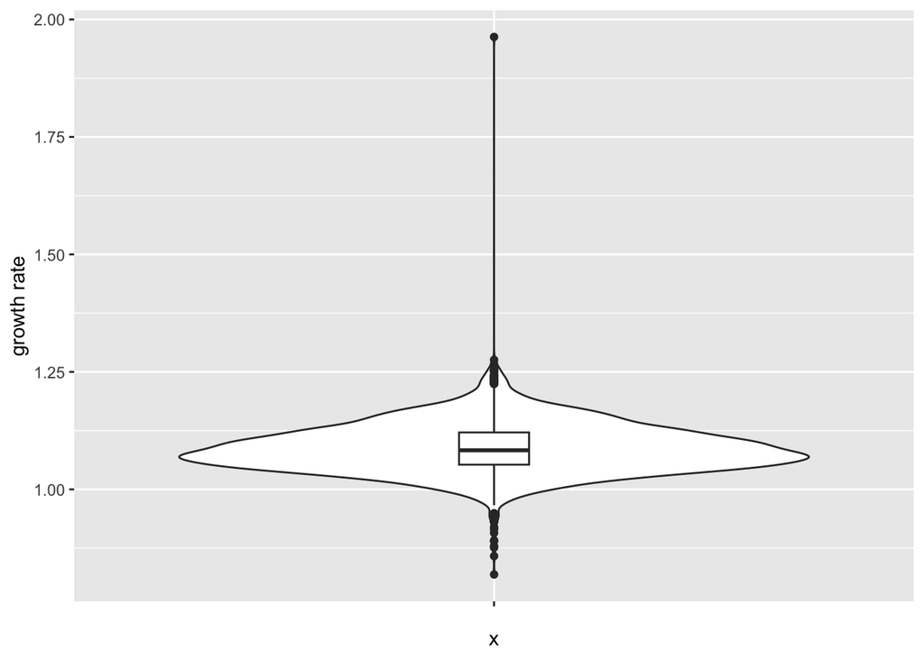

```r
ggplot(data=df,aes(x='',y=r)) + geom_violin() + geom_boxplot(width=0.1)+scale_y_continuous(name="growth rate")
```

It seems that the high growth rate is driven by two anomalous OD readings (in red)

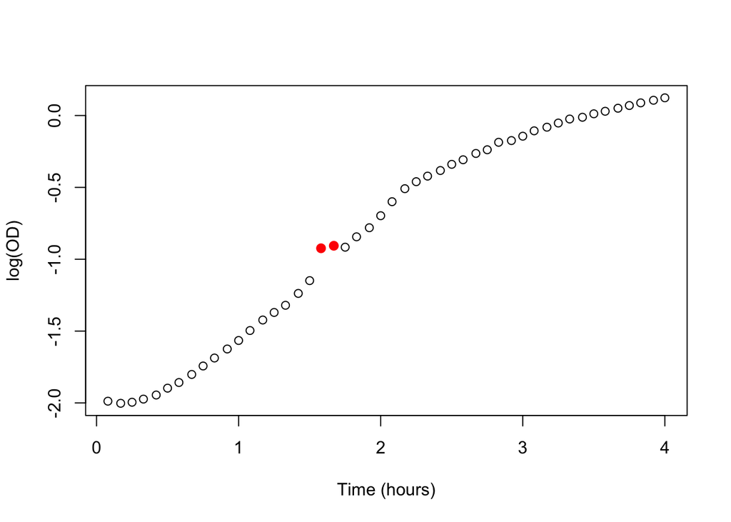

```r
plot(log(OD)~timepoint, data=subset(od_df, plate==23 & row=="H" & column==1), ylab="log(OD)", xlab="Time (hours)")
points(log(OD)~timepoint, data=subset(od_df, plate==23 & row=="H" & column==1 & timepoint>1.55 & timepoint<1.7), col="red", pch=16, cex=1.25)
```

Consequently, we also remove this data point:

```r
df<-subset(df, r<1.5)
```

Line 95 accumulated a mutation in the mismatch-repair gene *MutS* and consequently had an elevated mutation rate with 17 fixed mutations observed. There is evidence from the sequencing data that an additional five mutations arose after mutation accumulation but prior to sequencing. Given new mutations are also likely to arise during the growth assay, and data from this line are likely to have high leverage (all other lines had between zero and five), we removed this line from the analysis:

```r
df<-subset(df, line!=95)
```

## 3.1 Empty wells

40 replicates were not assayed because the initial culture looked like it hadn’t grown, with certain lines being overrepresented. If the initial culture did not grow because of the accumulated mutations in the line, this will bias our estimates of the DFE. However, if we compare the growth rates of lines where at least one replicate was excluded with the growth rates of lines where no replicates were excluded the difference is small and non-significant:

```r
nz_empty<-n_empty[which(n_empty!=0)]
summary(lm(r~as.factor(line%in%nz_empty), data=df))
```

```
##
## Call:
## lm(formula = r ~ as.factor(line %in% nz_empty), data = df)
##
## Residuals:
##       Min        1Q    Median        3Q       Max
## -0.268870 -0.035068 -0.004517  0.033388  0.187799
##
## Coefficients:
##                                    Estimate Std. Error  t value Pr(>|t|)
## (Intercept)                        1.087797   0.001040 1045.760   <2e-16 ***
## as.factor(line %in% nz_empty)TRUE -0.008608   0.006338   -1.358    0.175
## ---
## Signif. codes:  0 '***' 0.001 '**' 0.01 '*' 0.05 '.' 0.1 ' ' 1
##
## Residual standard error: 0.05231 on 2597 degrees of freedom
## Multiple R-squared:  0.0007098,  Adjusted R-squared:  0.000325
## F-statistic: 1.845 on 1 and 2597 DF,  p-value: 0.1745
```

Indeed, if we plot the growth rates of the four lines with the most replicates excluded (the coloured points) they do not obviously grow more slowly than other lines:

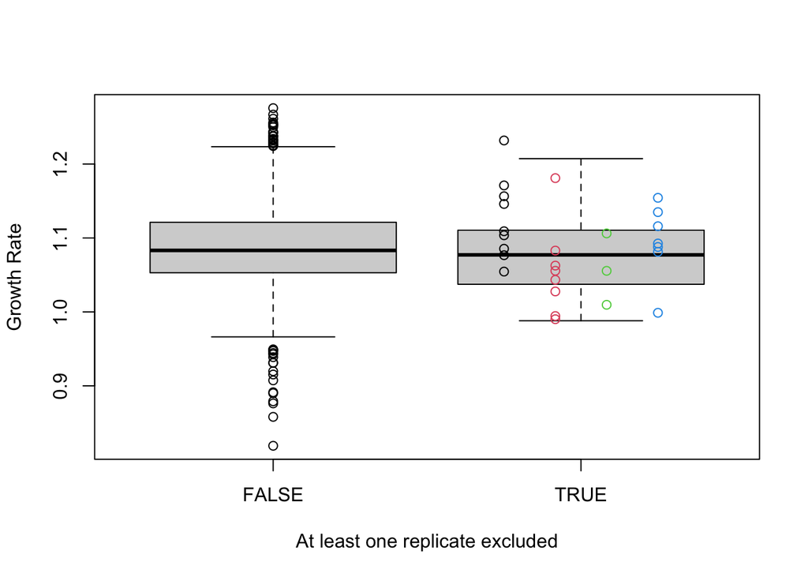

```r
boxplot(r~as.factor(line%in%nz_empty), data=df, ylab="Growth Rate", xlab="At least one replicate excluded")

worst_four<-subset(df, line%in%names(nz_empty)[which(nz_empty>4)])

points(r~I(2+(as.numeric(as.factor(line))-2.5)/6), col=as.numeric(as.factor(line)), data=worst_four)
```

and the line (in red) with the lowest average growth rate actually has no mutations:

```r
with(worst_four, n[match(levels(as.factor(line)), line)])
```

```
## [1] 1 0 1 1
```

# 4 Models

## 4.1 Main model

We fit a linear mixed model to the maximum growth rates with the aim of estimating the mean and variance of the distribution of fitness effects of new mutations (DFE) and the environment experienced by a line (EDFE).

```r
library(lmerTest)

m1<-lmer(r~n + anc + person + inner + (noanc-1|line) + (sqrt(n)-1|line) + (1|plate) + (1|plate:column) + (1|plate:row), data=df)
```

The basic biological model is:

$$\begin{equation}
r_{ij} = \beta_0+\delta^{(A)}_i\beta_A+n_i\beta_M+(1-\delta^{(A)}_i)u^{(E)}_i+\sqrt{n_i}u^{(M)}_i+e_{ij}
\end{equation}$$

where $r_{ij}$ is the maximum growth rate of replicate $j$ from line $i$. When the line is an ancestral line, $\delta^{(A)}$ (`anc`) is one but is zero for MA lines. $n_i$ (`n`) is the number of called mutations, which may be zero even for MA lines.

The fixed effects are

- $\beta_0$ is the expected growth rate of a zero-mutant MA line: `(Intercept)`
- $\beta_M$ is the linear change in fitness per mutation, related to the mean of the DFE: `n`.
- $\beta_A$ is the effect of a line being an ancestor: `anc`

The random effects are

- $u^{(M)}_i$ is the average effect of each mutation in MA line $i$. The variance of these effects ($\sigma^2_M$) is related to the variance of the DFE: `(sqrt(n)-1|line)`
- $u^{(E)}_i$ is the expected effect of MA line $i$ had the number of new mutations been zero. The variance of these effects is the variance of the EDFE ($\sigma^2_E$): `(noanc-1|line)`
- $e_{ij}$ the residual for replicate $j$ of $i$ with variance $\sigma^2_e$.

We also control for technical variation. The fixed effects are

- `person`: effect of the person inoculating the cultures.
- `inner`: effect of whether growth rates are different in inner wells.

The random effects are

- `(1|plate)`: effect of being on a specific plate.
- `(1|plate:column)`: effect of being in a specific column of a specific plate.
- `(1|plate:row)`: effect of being in a specific row of a specific plate.

The model summary is:

```r
summary(m1)
```

```
## Linear mixed model fit by REML. t-tests use Satterthwaite's method [
## lmerModLmerTest]
## Formula: r ~ n + anc + person + inner + (noanc - 1 | line) + (sqrt(n) -
##     1 | line) + (1 | plate) + (1 | plate:column) + (1 | plate:row)
##    Data: df
##
## REML criterion at convergence: -9436
##
## Scaled residuals:
##     Min      1Q  Median      3Q     Max
## -4.7550 -0.6015 -0.0610  0.5026  3.7585
##
## Random effects:
##  Groups       Name        Variance  Std.Dev.
##  plate.column (Intercept) 4.954e-05 7.038e-03
##  plate.row    (Intercept) 1.815e-04 1.347e-02
##  line         sqrt(n)     1.136e-12 1.066e-06
##  line.1       noanc       3.208e-04 1.791e-02
##  plate        (Intercept) 1.083e-03 3.291e-02
##  Residual                 1.172e-03 3.423e-02
## Number of obs: 2599, groups:
## plate:column, 336; plate:row, 224; line, 188; plate, 28
##
## Fixed effects:
##               Estimate Std. Error         df t value Pr(>|t|)
## (Intercept)  1.088e+00  9.252e-03  2.961e+01 117.575  < 2e-16 ***
## n           -2.584e-04  1.373e-03  1.846e+02  -0.188  0.85091
## anc          2.736e-02  5.339e-03  2.261e+03   5.124 3.24e-07 ***
## personJDH    6.857e-03  1.267e-02  2.603e+01   0.541  0.59293
## inner       -5.776e-03  1.899e-03  7.404e+02  -3.041  0.00244 **
## ---
## Signif. codes:  0 '***' 0.001 '**' 0.01 '*' 0.05 '.' 0.1 ' ' 1
##
## Correlation of Fixed Effects:
##           (Intr) n      anc    prsJDH
## n         -0.162
## anc       -0.093  0.276
## personJDH -0.685  0.003  0.000
## inner     -0.129 -0.001  0.027  0.000
## optimizer (nloptwrap) convergence code: 0 (OK)
## boundary (singular) fit: see help('isSingular')
```

The biological findings of this model are:

- Assuming no cell death, we can divide $ln(2)$ by the intercept to get an estimate of the generation time of a zero-mutatnt line (grown in an outer well and inoculated by DN): 38 minutes.
- The `n` effect ($\beta_M$) is the expected change in growth rate caused by a single mutation - it is small and not significantly different from zero.
- The `anc` effect ($\beta_A$) is positive, suggesting that the ancestral line grows faster than the average growth rate of the zero-mutant lines.
- The `line.1` (`noanc`) variance ($\sigma^2_E$) due to between-line differences not caused by mutations explains approximately 11% of the total variance (after controlling for the fixed effects).
- The `line` (`sqrt(n)`) variance ($\sigma^2_M$) is bound at zero suggesting that single mutations generate very little, if any, between-line variance.

We can use the DHARMa package to assess the model fit:

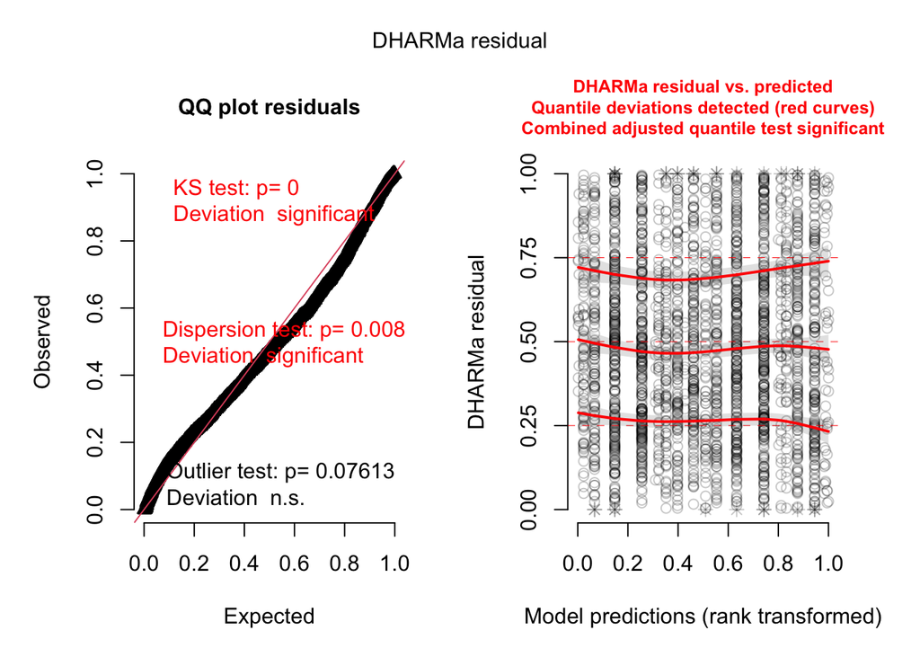

```r
library(DHARMa)
simres<-simulateResiduals(m1)
plot(simres)
```

While there are significant deviations from expectation, the magnitude of the deviations are rather small.

We can also plot the data and some model predictions in order to get a feel for what the model is telling us

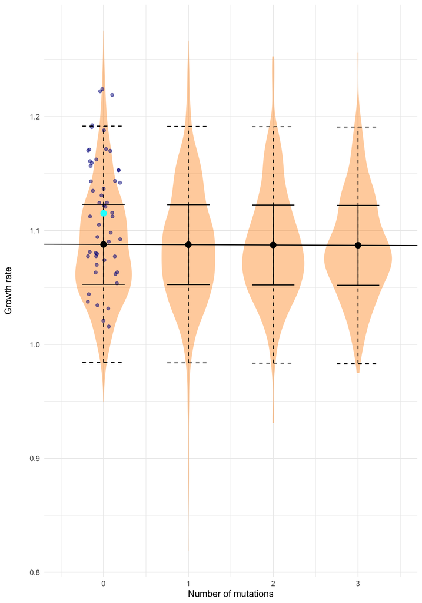

Figure 4.1: Growth rate (log(OD) per hour) for lines grouped by number of accumulated mutations. The distribution of replicates from non-ancestral lines are represented as an orange violin plot and replicates of ancestral lines are in blue. The solid black line is the fitted regression with black dots representing the predicted mean fitness for lines with different numbers of mutation. The whiskers indicate the 95% quantiles for the line effects (full black bars) and the observations (dashed black bars). The cyan data point is the estimated mean ancestral growth rate.

```r
intercept=fixef(m1)['(Intercept)']
mutation_effect=fixef(m1)['n']
ancestor_effect=fixef(m1)['anc']

env_variance<-as.numeric(VarCorr(m1)[['line.1']])
tech_variance<-as.numeric(VarCorr(m1)[['plate.column']]+VarCorr(m1)[['plate.row']]+VarCorr(m1)[['plate']])
mut_variance<-as.numeric(VarCorr(m1)[['line']])
res_variance<-sigma(m1)^2

pred_mutations<-0:3

pred_mean<-intercept+mutation_effect*pred_mutations
pred_var<-env_variance+res_variance+mut_variance*pred_mutations+tech_variance
pred_bl_var<-env_variance+mut_variance*pred_mutations

pred_ancestor<-intercept+ancestor_effect

pred_lower_q<-qnorm(0.025,pred_mean,sqrt(pred_var))
pred_upper_q<-qnorm(0.975,pred_mean,sqrt(pred_var))

pred_lower_q_bl<-qnorm(0.025,pred_mean,sqrt(pred_bl_var))
pred_upper_q_bl<-qnorm(0.975,pred_mean,sqrt(pred_bl_var))

plot_data<-cbind(pred_mutations,pred_mean,pred_lower_q,pred_upper_q,pred_lower_q_bl,pred_upper_q_bl)

df_plot <- df %>%
  mutate(point_col = case_when(
    noanc == 0                          ~ "blue",
    n <= 3 & noanc == 1          ~ "orange",
    TRUE                                ~ "other")
  )

df_plot<-df_plot[order(df_plot$point_col, decreasing=TRUE),]

CI <- ggplot(plot_data, aes(pred_mutations, pred_mean)) +

  ## a1) violin for orange data -----------------
  geom_violin(data   = filter(df_plot, point_col == "orange"),
              aes(x = n, y = r, group = n),
              fill   = "darkorange", alpha = .4,
              colour = NA,            # remove outline; set a colour if preferred
              width  = .8,
              show.legend = FALSE) +

  ## a2) jittered blue points ------------------
  geom_jitter(data = filter(df_plot, point_col == "blue"),
              aes(x = n, y = r, colour = point_col),
              width  = .20, height = 0, alpha = .5, show.legend = FALSE) +

  scale_colour_manual(values = c(blue = "darkblue")) +

  ## b) regression line ------------------------
  geom_abline(intercept = intercept, slope = mutation_effect) +

  ## c) fitted means & error bars --------------
  geom_point(size = 3) +
  geom_errorbar(aes(ymin = pred_upper_q, ymax = pred_lower_q),
                width = .5, colour = "black", linetype = "dashed") +
  geom_errorbar(aes(ymin = pred_upper_q_bl, ymax = pred_lower_q_bl),
                width = .5, colour = "black") +

  ## d) ancestor point -------------------------
  annotate("point", x = 0, y = pred_ancestor, colour = "cyan", size = 3, alpha = 1) +

  ## e) axes, labels, limits -------------------
  scale_x_continuous(limits = c(-.5, 3.5),
                     name   = "Number of mutations") +
  ylab("Growth rate") +

  ## f) theme ----------------------------------
  theme_minimal(base_size = 11) +
  theme(
    axis.title   = element_text(size = 11),
    axis.title.y = element_text(margin = margin(t = 10, r = 20, b = 20))
  )
  plot(CI)
```

```r
  if(save){
  ggsave(file.path(root,'models/fitness.jpeg'),width = 5, height = 4,units='in')
  }
```

There seems to be quite a few reduced growth rates in the single mutant class - many of these are associated with line 45 which has a frameshift mutation in the *SspA* gene:

```r
table(subset(df, r<0.95)$line)
```

```
##
## 103 115 117  18 218  45  98
##   1   2   1   2   1  10   1
```

We can highlight the data points in this line in red.

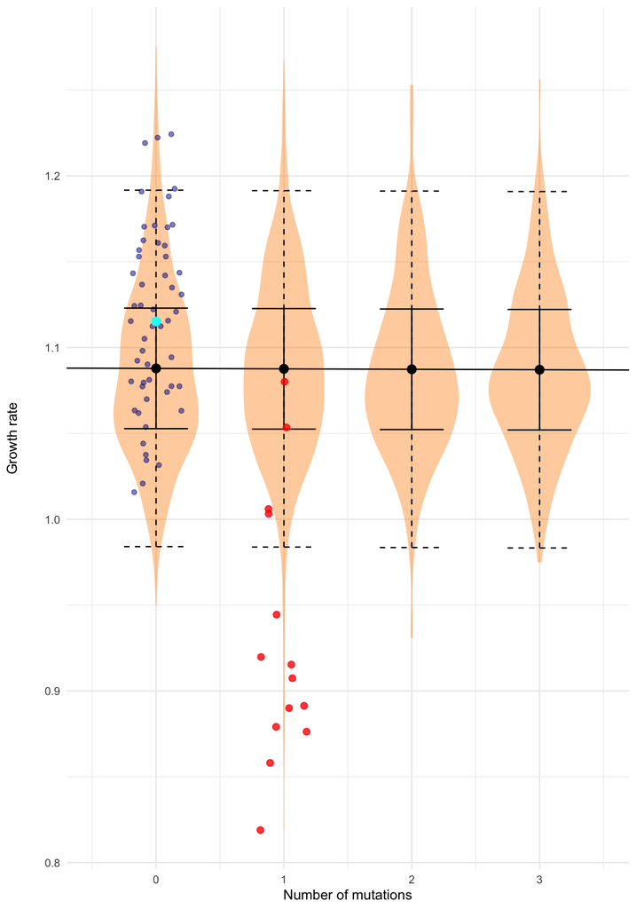

Figure 4.2: Growth rate (log(OD) per hour) for lines grouped by number of accumulated mutations. The distribution of replicates from non-ancestral lines are represented as an orange violin plot and replicates of ancestral lines are in blue. The solid black line is the fitted regression with black dots representing the predicted mean fitness for lines with different numbers of mutation. The whiskers indicate the 95% quantiles for the line effects (full black bars) and the observations (dashed black bars). The cyan data point is the estimated mean ancestral growth rate and the red points are from line 45

```r
df_45 <- df_plot %>%filter(line == 45)
CI2 <- CI +                                          # start from CI
  geom_jitter(data = df_45,                   # only these rows
              aes(x = n, y = r),             # same aesthetics
              width  = .20, height = 0,
              colour = "red",                        # fixed colour
              size   = 2.2, alpha = .8,
              show.legend = FALSE)
  plot(CI2)
```

```r
   if(save){
  ggsave(file.path(root,'models/fitness2.jpeg'),width = 5, height = 4,units='in')
  }
```

We can also check to make sure that the between-line variance in zero-mutant lines isn’t been driven by one or two extreme lines (the cyan point is for the ancestor):

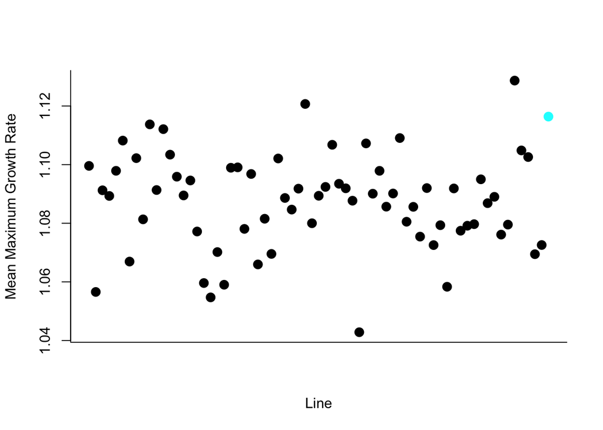

Figure 4.3: Raw mean growth rates for lines without mutations with the ancestor in cyan.

```r
zero_m_means<-with(df_plot %>% filter(n == 0), tapply(r, line, mean))

plot(zero_m_means, col=c("black", "cyan")[(names(zero_m_means)=="anc")+1], pch=16, cex=1.5, bty="l", ylab="Mean Maximum Growth Rate", xaxt='n', xlab="Line")
```

The line means take on a range of values without any obvious outliers or bimodality, suggesting missed mutations or rare but extreme environmental effects cannot explain the results. The ancestor also has a growth rate that exceeds the average by some margin, but is not necessarily unusual with respect to the distribution of line means (see below).

## 4.2 Obtaining the DFE

The previous model provides a model for the growth rates of each line. However, to obtain the DFE we need to compute the distribution of relative fitnesses for single-mutant lines compared to zero-mutant lines. The expected growth rate of zero-mutant lines ($r_w$) is the intercept, $\beta_0$.

$$\begin{equation}
r_w = \beta_0
\end{equation}$$

The expected growth rate of line $i$ is

$$\begin{equation}
r_i = \beta_0 + n_i\beta_M+\sqrt{n_i}u^{(M)}_i
\end{equation}$$

where the expectation is taken over the distribution of environmental effects.

The selection coefficient for MA line $i$ is $r_i-r_w$, although this is in units *per hour* and is therefore hard to compare across studies and species (see Equation 2.2 in Chevin (2011) and Equation 7 in Fink and Manhart (2024)). To make selection coefficients more comparable, they can be put on the scale of generations by using Equation 3.2 in Chevin (2011):

$$\begin{equation}
s_i=\frac{r_i-r_w}{r_w}ln(2)
\end{equation}$$

Setting $n=1$, the distribution of generation-scaled fitness effects (the DFE) from our model is normal with mean

$$\begin{equation}
\mu_s = \frac{\beta_M}{\beta_0}ln(2)
\end{equation}$$

and variance

$$\begin{equation}
\sigma^2_s = \frac{\sigma^2_M}{\beta_0^2}ln(2)^2
\end{equation}$$

Since the mean and the variance of the DFE are functions of model parameters we refit model `m1` using Markov chain Monte Carlo in order to obtain credible intervals.

```r
library(MCMCglmm)

m1_mcmc<-MCMCglmm(r~n+anc+person+inner,
                  random=~line+idh(sqrt(n)):line+plate+plate:column+plate:row,
                  data=as.data.frame(df),
                  prior=list(R=IW(1, 0.002), G=F(1,10)),
                  longer=10, verbose=FALSE)
```

The model estimates are very close to those obtained using restricted maximum likelihood (REML):

```r
summary(m1_mcmc)
```

```
##
##  Iterations = 30001:129901
##  Thinning interval  = 100
##  Sample size  = 1000
##
##  DIC: -9789.545
##
##  G-structure:  ~line
##
##      post.mean  l-95% CI u-95% CI eff.samp
## line 0.0002968 0.0001684 0.000396     1128
##
##                ~idh(sqrt(n)):line
##
##              post.mean  l-95% CI u-95% CI eff.samp
## sqrt(n).line 3.705e-05 1.611e-10 0.000147     1000
##
##                ~plate
##
##       post.mean  l-95% CI u-95% CI eff.samp
## plate  0.001241 0.0006452  0.00203    824.1
##
##                ~plate:column
##
##              post.mean  l-95% CI  u-95% CI eff.samp
## plate:column 4.869e-05 1.371e-05 8.225e-05      868
##
##                ~plate:row
##
##           post.mean l-95% CI  u-95% CI eff.samp
## plate:row 0.0001854 0.000129 0.0002435     1128
##
##  R-structure:  ~units
##
##       post.mean l-95% CI u-95% CI eff.samp
## units  0.001176 0.001099 0.001247     1000
##
##  Location effects: r ~ n + anc + person + inner
##
##              post.mean   l-95% CI   u-95% CI eff.samp  pMCMC
## (Intercept)  1.0879896  1.0712298  1.1085679     1115 <0.001 ***
## n           -0.0004609 -0.0033967  0.0024213     1000  0.748
## anc          0.0266845 -0.0053996  0.0666236     1000  0.118
## personJDH    0.0070891 -0.0154908  0.0341886     1000  0.610
## inner       -0.0057090 -0.0094046 -0.0021757     1000  0.002 **
## ---
## Signif. codes:  0 '***' 0.001 '**' 0.01 '*' 0.05 '.' 0.1 ' ' 1
```

and the conclusions drawn from the posterior distributions of the biological fixed effects and variance components are consistent with those obtained using REML:

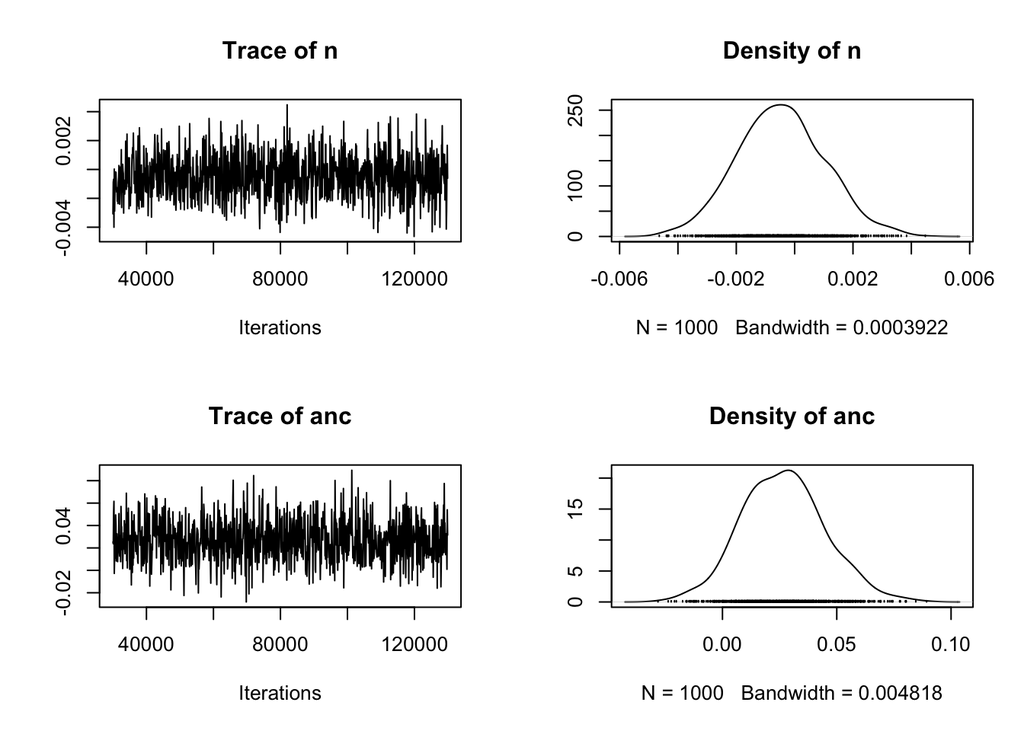

```r
plot(m1_mcmc$Sol[,c("n", "anc")])
```

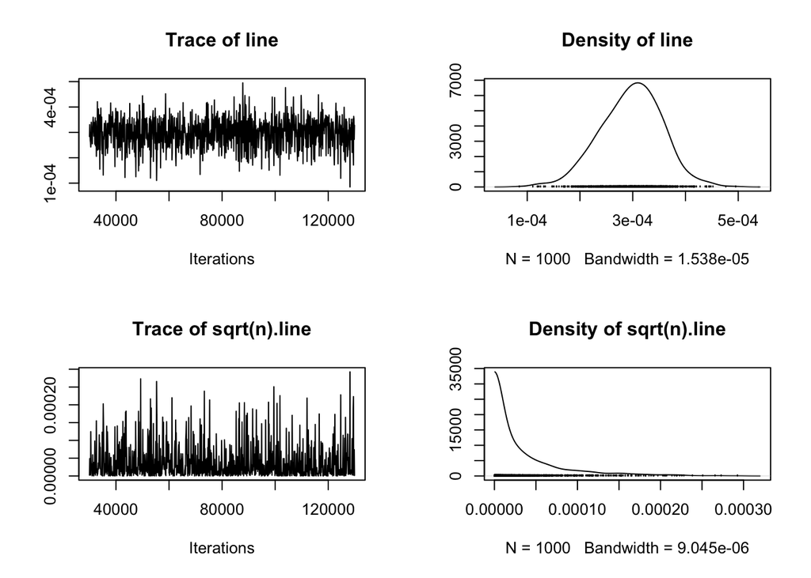

```r
plot(m1_mcmc$VCV[,c("line", "sqrt(n).line")])
```

We can obtain the posterior distributions for the mean and variance of the DFE

```r
mean_s<-log(2)*m1_mcmc$Sol[,"n"]/m1_mcmc$Sol[,"(Intercept)"]

mean(mean_s)
```

```
## [1] -0.0002923119
```

```r
HPDinterval(mean_s)
```

```
##             lower       upper
## var1 -0.002158291 0.001526505
## attr(,"Probability")
## [1] 0.95
```

```r
var_s<-(log(2)^2)*m1_mcmc$VCV[,"sqrt(n).line"]/m1_mcmc$Sol[,"(Intercept)"]^2

mean(var_s)
```

```
## [1] 1.504676e-05
```

```r
HPDinterval(var_s)
```

```
##             lower        upper
## var1 6.576648e-11 5.933546e-05
## attr(,"Probability")
## [1] 0.95
```

### 4.2.1 Estimating the DFE using the ancestor as a reference

Most studies do not have zero-mutant lines to which they can compare the fitness of lines carrying mutations. This is only valid if all between-line variance is due to mutations. If we had used the ancestor as the reference then

$$\begin{equation}
r_w = \beta_0+\beta_A
\end{equation}$$

where $\beta_A$ is the effect of the ancestor. The mean and variance of the DFE would then be:

$$\begin{equation}
%\mu_s = \frac{\beta_0+\beta_M-\beta_0-\beta_A}{\beta_0+\beta_A}ln(2)
\mu_s = \frac{\beta_M-\beta_A}{\beta_0+\beta_A}ln(2)
\end{equation}$$

and

$$\begin{equation}
\sigma^2_s = \frac{\sigma^2_M}{(\beta_0+\beta_A)^2}ln(2)^2
\end{equation}$$

which gives

```r
mean_s2<-log(2)*(m1_mcmc$Sol[,"n"]-m1_mcmc$Sol[,"anc"])/(m1_mcmc$Sol[,"(Intercept)"]+m1_mcmc$Sol[,"anc"])

mean(mean_s2)
```

```
## [1] -0.016699
```

```r
HPDinterval(mean_s2)
```

```
##            lower       upper
## var1 -0.03973571 0.003393257
## attr(,"Probability")
## [1] 0.95
```

```r
var_s2<-(log(2)^2)*m1_mcmc$VCV[,"sqrt(n).line"]/(m1_mcmc$Sol[,"(Intercept)"]+m1_mcmc$Sol[,"anc"])^2

mean(var_s2)
```

```
## [1] 1.435925e-05
```

```r
HPDinterval(var_s2)
```

```
##             lower       upper
## var1 6.240595e-11 5.65539e-05
## attr(,"Probability")
## [1] 0.95
```

## 4.3 Is the ancestor effect comparable to other zero-mutant line effects?

```r
m2<-lmer(r ~ n + anc + person + inner + (1|line) + (sqrt(n)-1|line) + (1|plate) + (1|plate:column) + (1|plate:row), data=df)
summary(m2)
```

```
## Linear mixed model fit by REML. t-tests use Satterthwaite's method [
## lmerModLmerTest]
## Formula: r ~ n + anc + person + inner + (1 | line) + (sqrt(n) - 1 | line) +
##     (1 | plate) + (1 | plate:column) + (1 | plate:row)
##    Data: df
##
## REML criterion at convergence: -9436
##
## Scaled residuals:
##     Min      1Q  Median      3Q     Max
## -4.7550 -0.6015 -0.0610  0.5026  3.7585
##
## Random effects:
##  Groups       Name        Variance  Std.Dev.
##  plate.column (Intercept) 4.954e-05 7.038e-03
##  plate.row    (Intercept) 1.815e-04 1.347e-02
##  line         sqrt(n)     1.403e-12 1.184e-06
##  line.1       (Intercept) 3.208e-04 1.791e-02
##  plate        (Intercept) 1.083e-03 3.291e-02
##  Residual                 1.172e-03 3.423e-02
## Number of obs: 2599, groups:
## plate:column, 336; plate:row, 224; line, 188; plate, 28
##
## Fixed effects:
##               Estimate Std. Error         df t value Pr(>|t|)
## (Intercept)  1.088e+00  9.252e-03  2.961e+01 117.575  < 2e-16 ***
## n           -2.584e-04  1.373e-03  1.846e+02  -0.188  0.85090
## anc          2.736e-02  1.869e-02  1.282e+02   1.464  0.14567
## personJDH    6.857e-03  1.267e-02  2.603e+01   0.541  0.59293
## inner       -5.776e-03  1.899e-03  7.404e+02  -3.041  0.00244 **
## ---
## Signif. codes:  0 '***' 0.001 '**' 0.01 '*' 0.05 '.' 0.1 ' ' 1
##
## Correlation of Fixed Effects:
##           (Intr) n      anc    prsJDH
## n         -0.162
## anc       -0.027  0.079
## personJDH -0.685  0.003  0.000
## inner     -0.129 -0.001  0.008  0.000
## optimizer (nloptwrap) convergence code: 0 (OK)
## boundary (singular) fit: see help('isSingular')
```

## 4.4 Mutation type

In the previous models all mutations are treated as being equivalent. However, we might expect synonymous mutations and small structural mutations in non-coding regions to have negligible fitness effects compared to other mutations. We can count the number of mutations per line that are not of this type (`nsyn_mutation`)

```r
nsyn_mutations<-subset(mutations, (nchar(REF)!=nchar(ALT) & coding) | ALT=="<DEL>" | type%in%c("nonsynonymous", "nonsense", "frameshift"))
nnsyn_mutations<-table(factor(nsyn_mutations$line, levels=unique(df$line)))
df$nsyn_mutation<-as.numeric(nnsyn_mutations[df$line])
```

and rerun model with this as a predictor

```r
m3<-lmer(r ~ nsyn_mutation + anc + person + inner + (noanc-1|line) + (sqrt(nsyn_mutation)-1|line) + (1|plate) + (1|plate:column) + (1|plate:row),data=df)
summary(m3)
```

```
## Linear mixed model fit by REML. t-tests use Satterthwaite's method [
## lmerModLmerTest]
## Formula: r ~ nsyn_mutation + anc + person + inner + (noanc - 1 | line) +
##     (sqrt(nsyn_mutation) - 1 | line) + (1 | plate) + (1 | plate:column) +
##     (1 | plate:row)
##    Data: df
##
## REML criterion at convergence: -9437.9
##
## Scaled residuals:
##     Min      1Q  Median      3Q     Max
## -4.7136 -0.5992 -0.0598  0.5067  3.8460
##
## Random effects:
##  Groups       Name                Variance  Std.Dev.
##  plate.column (Intercept)         4.959e-05 0.007042
##  plate.row    (Intercept)         1.820e-04 0.013491
##  line         sqrt(nsyn_mutation) 9.598e-05 0.009797
##  line.1       noanc               2.641e-04 0.016252
##  plate        (Intercept)         1.083e-03 0.032910
##  Residual                         1.171e-03 0.034225
## Number of obs: 2599, groups:
## plate:column, 336; plate:row, 224; line, 188; plate, 28
##
## Fixed effects:
##                 Estimate Std. Error         df t value Pr(>|t|)
## (Intercept)    1.089e+00  9.187e-03  2.877e+01 118.502  < 2e-16 ***
## nsyn_mutation -1.719e-03  2.022e-03  5.535e+01  -0.850  0.39902
## anc            2.655e-02  5.225e-03  2.038e+03   5.082 4.08e-07 ***
## personJDH      6.837e-03  1.267e-02  2.603e+01   0.540  0.59402
## inner         -5.819e-03  1.900e-03  7.406e+02  -3.063  0.00227 **
## ---
## Signif. codes:  0 '***' 0.001 '**' 0.01 '*' 0.05 '.' 0.1 ' ' 1
##
## Correlation of Fixed Effects:
##             (Intr) nsyn_m anc    prsJDH
## nsyn_mutatn -0.112
## anc         -0.070  0.193
## personJDH   -0.690  0.002  0.000
## inner       -0.130  0.005  0.029  0.000
```

We find that even when we only look at mutations that likely have a stronger effect on fitness, mutations do not significantly influence growth rate.

## 4.5 Can the results be explained by variation in OD at the start or when the maximum growth rate is achieved?

A common practice when measuring bacterial growth curves is to standardise the inoculation cell density to minimize any influence of starting density on growth curve parameter estimates. This what not feasible given the level of throughput, we can attempt to control for starting density (`startOD`) statistically. However, there is the danger that we control for some of the fitness variation we seek to measure if the fast growth of a line results in high starting density.

```r
m4<-lmer(r ~ n + anc + person + inner + log(startOD) + (noanc-1|line) + (sqrt(n)-1|line) + (1|plate) + (1|plate:column) + (1|plate:row),data=df)
summary(m4)
```

```
## Linear mixed model fit by REML. t-tests use Satterthwaite's method [
## lmerModLmerTest]
## Formula: r ~ n + anc + person + inner + log(startOD) + (noanc - 1 | line) +
##     (sqrt(n) - 1 | line) + (1 | plate) + (1 | plate:column) +
##     (1 | plate:row)
##    Data: df
##
## REML criterion at convergence: -9432.3
##
## Scaled residuals:
##     Min      1Q  Median      3Q     Max
## -5.0424 -0.5960 -0.0601  0.5024  3.7505
##
## Random effects:
##  Groups       Name        Variance  Std.Dev.
##  plate.column (Intercept) 4.993e-05 0.007066
##  plate.row    (Intercept) 1.923e-04 0.013866
##  line         sqrt(n)     0.000e+00 0.000000
##  line.1       noanc       3.060e-04 0.017493
##  plate        (Intercept) 1.089e-03 0.032995
##  Residual                 1.170e-03 0.034206
## Number of obs: 2599, groups:
## plate:column, 336; plate:row, 224; line, 188; plate, 28
##
## Fixed effects:
##                Estimate Std. Error         df t value Pr(>|t|)
## (Intercept)   1.145e+00  3.498e-02  1.672e+03  32.741  < 2e-16 ***
## n            -1.775e-04  1.349e-03  1.771e+02  -0.132  0.89546
## anc           2.512e-02  5.476e-03  2.294e+03   4.588 4.71e-06 ***
## personJDH     6.935e-03  1.271e-02  2.602e+01   0.546  0.58990
## inner        -6.200e-03  1.924e-03  7.564e+02  -3.224  0.00132 **
## log(startOD)  2.891e-02  1.698e-02  2.199e+03   1.703  0.08872 .
## ---
## Signif. codes:  0 '***' 0.001 '**' 0.01 '*' 0.05 '.' 0.1 ' ' 1
##
## Correlation of Fixed Effects:
##             (Intr) n      anc    prsJDH inner
## n           -0.007
## anc         -0.248  0.256
## personJDH   -0.178  0.003  0.000
## inner       -0.142 -0.005  0.052 -0.001
## log(strtOD)  0.964  0.036 -0.233  0.004 -0.112
## optimizer (nloptwrap) convergence code: 0 (OK)
## boundary (singular) fit: see help('isSingular')
```

The effect of (log) starting density on the maximum growth rate is small and non-significant, and the impact on other model parameters is negligible.

It is well known that OD is only directly proportional to cell density at low densities, and at high densities the relationship becomes shallower than one (Lawrence and Maier 1977). Consequently, replicates that achieve their maximum growth rate at high densities will have their maximum growth rate underestimated. If the density at which maximum growth rate is achieved systematically varies over lines, then this bias in maximum growth rate will appear as between-line variance. To test for this we can control for the density at which the maximum growth rate is achieved (`midOD`):

```r
m5<-lmer(r ~ n + anc + person + inner + log(midOD) + (noanc-1|line) + (sqrt(n)-1|line) + (1|plate) + (1|plate:column) + (1|plate:row),data=df)
summary(m5)
```

```
## Linear mixed model fit by REML. t-tests use Satterthwaite's method [
## lmerModLmerTest]
## Formula: r ~ n + anc + person + inner + log(midOD) + (noanc - 1 | line) +
##     (sqrt(n) - 1 | line) + (1 | plate) + (1 | plate:column) +
##     (1 | plate:row)
##    Data: df
##
## REML criterion at convergence: -9428
##
## Scaled residuals:
##     Min      1Q  Median      3Q     Max
## -4.8076 -0.6001 -0.0683  0.5021  3.7488
##
## Random effects:
##  Groups       Name        Variance  Std.Dev.
##  plate.column (Intercept) 4.899e-05 6.999e-03
##  plate.row    (Intercept) 1.812e-04 1.346e-02
##  line         sqrt(n)     7.693e-13 8.771e-07
##  line.1       noanc       3.154e-04 1.776e-02
##  plate        (Intercept) 1.083e-03 3.291e-02
##  Residual                 1.173e-03 3.425e-02
## Number of obs: 2599, groups:
## plate:column, 336; plate:row, 224; line, 188; plate, 28
##
## Fixed effects:
##               Estimate Std. Error         df t value Pr(>|t|)
## (Intercept)  1.091e+00  9.578e-03  3.400e+01 113.929  < 2e-16 ***
## n           -2.436e-04  1.364e-03  1.830e+02  -0.179  0.85845
## anc          2.690e-02  5.347e-03  2.273e+03   5.031 5.27e-07 ***
## personJDH    6.863e-03  1.267e-02  2.603e+01   0.542  0.59255
## inner       -5.703e-03  1.899e-03  7.405e+02  -3.003  0.00277 **
## log(midOD)   4.042e-03  3.027e-03  2.461e+03   1.335  0.18191
## ---
## Signif. codes:  0 '***' 0.001 '**' 0.01 '*' 0.05 '.' 0.1 ' ' 1
##
## Correlation of Fixed Effects:
##            (Intr) n      anc    prsJDH inner
## n          -0.153
## anc        -0.105  0.274
## personJDH  -0.662  0.003  0.000
## inner      -0.117 -0.001  0.025  0.000
## log(midOD)  0.260  0.008 -0.065  0.000  0.028
## optimizer (nloptwrap) convergence code: 0 (OK)
## boundary (singular) fit: see help('isSingular')
```

Again, the effect of (log) density on the maximum growth rate is small and non-significant, and the impact on other model parameters is negligible.

## 4.6 Significance testing of random effect variances

To test the significance of the fixed effects we use t-tests with the degrees of freedom obtained using the Satterthwaite approximation as implemented in `lmerTest`. To test the significance of the random effects we perform likelihood ratio tests implemented in the $\texttt{anova}$ method for lmer objects (although we note that the p-values could be halved (Chernoff 1954)).

### 4.6.1 Genetic line effects

We can omit the term `(sqrt(n)-1|line)` from model `m1` to test whether the variance of the DFE is non-zero

```r
m6<-lmer(r ~ n + anc + person + inner + (noanc-1|line) + (1|plate) + (1|plate:column) + (1|plate:row),data=df)
anova(m6,m1)
```

```
## Data: df
## Models:
## m6: r ~ n + anc + person + inner + (noanc - 1 | line) + (1 | plate) + (1 | plate:column) + (1 | plate:row)
## m1: r ~ n + anc + person + inner + (noanc - 1 | line) + (sqrt(n) - 1 | line) + (1 | plate) + (1 | plate:column) + (1 | plate:row)
##    npar     AIC     BIC logLik -2*log(L) Chisq Df Pr(>Chisq)
## m6   10 -9461.9 -9403.3   4741   -9481.9
## m1   11 -9459.9 -9395.4   4741   -9481.9     0  1          1
```

The evidence is not strong

### 4.6.2 Environmental line effects

We can omit the term `(noanc-1|line)` from model `m1` to test whether the variance of the EDFE is non-zero

```r
m7<-lmer(r ~ n + anc + person + inner + (sqrt(n)-1|line) + (1|plate) + (1|plate:column) + (1|plate:row),data=df)
anova(m7,m1)
```

```
## Data: df
## Models:
## m7: r ~ n + anc + person + inner + (sqrt(n) - 1 | line) + (1 | plate) + (1 | plate:column) + (1 | plate:row)
## m1: r ~ n + anc + person + inner + (noanc - 1 | line) + (sqrt(n) - 1 | line) + (1 | plate) + (1 | plate:column) + (1 | plate:row)
##    npar     AIC     BIC logLik -2*log(L)  Chisq Df Pr(>Chisq)
## m7   10 -9405.5 -9346.9 4712.8   -9425.5
## m1   11 -9459.9 -9395.4 4741.0   -9481.9 56.431  1  5.821e-14 ***
## ---
## Signif. codes:  0 '***' 0.001 '**' 0.01 '*' 0.05 '.' 0.1 ' ' 1
```

There is strong evidence that lines vary in their fitness due to things other than the mutations they’ve accumulated.

# 5 Comparison with Sane, Miranda, and Agashe (2018)

Sane, Miranda, and Agashe (2018) also used an MA procedure where lines differ by single mutations. However, rather than running many lines for a short period of time and sequencing at the end, they ran fewer lines for a longer period and sequenced them periodically. Consequently, rather than comparing MA lines with a common unmutated ancestor, each line is compared to its ancestor prior to the accumulation of a single mutation. In total, 80 single mutations were assayed.

```r
df_long_Sane<-read.csv(file.path(root, "meta/Sane_data.csv"))
```

The data frame was kindly provided by Mrudula Sane and Deepa Agashe and contains three columns `abs_gr_1`, `abs_gr_2`, `abs_gr_3` which are the three replicate growth rate estimates for each line. `cognate_anc_gr` is the estimated growth rate of that line’s immediate ancestor (presumably the average of three replicates). The `rel_gr` column is the relative growth rate as used in the paper which is the average value of the `abs_gr` variables, divided by `cognate_anc_gr` (note this is equal to $1+(r_i-r_{w_i})/r_{w_i}$) where $r_{w_i}$ is the average growth rate of line $i$’s immediate ancestor.

We can turn this wide-format data-frame into long format with the three absolute growth rates appearing in the single column (`r`):

```r
df_Sane <- df_long_Sane[,c('mutation_id',"abs_gr_1", "abs_gr_2", "abs_gr_3","cognate_anc_gr", "transfer")] %>%
    pivot_longer(
        cols = c("abs_gr_1", "abs_gr_2", "abs_gr_3"),
        names_to = "replicate",
        values_to = "r"
    )
```

Ideally, we would have information for the replicate estimates that formed each `cognate_anc_gr` in order to model uncertainty in $r_w$. It would also have been good to know the line identity of the immediate ancestor, since the line may itself have acquired a single mutation from a more distant ancestor. Since this information is not available we will analyse $ln(2)(r_{ij}-r_{w_i})/r__{w_i}$

```r
df_Sane=df_Sane %>% mutate(s =log(2)*(r-cognate_anc_gr)/cognate_anc_gr)

m1_Sane<-lmer(s~(1|mutation_id),data=df_Sane)
```

```r
summary(m1_Sane)
```

```
## Linear mixed model fit by REML. t-tests use Satterthwaite's method [
## lmerModLmerTest]
## Formula: s ~ (1 | mutation_id)
##    Data: df_Sane
##
## REML criterion at convergence: -537.3
##
## Scaled residuals:
##     Min      1Q  Median      3Q     Max
## -2.1895 -0.3816  0.0241  0.3808  3.6548
##
## Random effects:
##  Groups      Name        Variance Std.Dev.
##  mutation_id (Intercept) 0.011143 0.10556
##  Residual                0.002506 0.05006
## Number of obs: 240, groups:  mutation_id, 80
##
## Fixed effects:
##             Estimate Std. Error       df t value Pr(>|t|)
## (Intercept)  0.03127    0.01224 79.00000   2.556   0.0125 *
## ---
## Signif. codes:  0 '***' 0.001 '**' 0.01 '*' 0.05 '.' 0.1 ' ' 1
```

The mean of the DFE (the intercept) exceeds zero by some margin and the variance of the DFE is also substantial and highly significant:

```r
m0_Sane<-lm(s~1,data=df_Sane)
anova(m1_Sane, m0_Sane)
```

```
## Data: df_Sane
## Models:
## m0_Sane: s ~ 1
## m1_Sane: s ~ (1 | mutation_id)
##         npar     AIC     BIC logLik -2*log(L)  Chisq Df Pr(>Chisq)
## m0_Sane    2 -348.13 -341.17 176.07   -352.13
## m1_Sane    3 -538.25 -527.81 272.12   -544.25 192.12  1  < 2.2e-16 ***
## ---
## Signif. codes:  0 '***' 0.001 '**' 0.01 '*' 0.05 '.' 0.1 ' ' 1
```

Part of the between-line variance will be driven by the fact that the same `cognate_anc_gr` value is used for each of the three replicate growth rates of a mutation. However, if we analyse the replicate growth rates of each line without normalising by the ancestor’s growth rate and generation time (i.e. the $r_{ij}$) we still see substantial between-line variance.

```r
m2_Sane<-lmer(r~(1|mutation_id),data=df_Sane)
```

```r
summary(m2_Sane)
```

```
## Linear mixed model fit by REML. t-tests use Satterthwaite's method [
## lmerModLmerTest]
## Formula: r ~ (1 | mutation_id)
##    Data: df_Sane
##
## REML criterion at convergence: -286.3
##
## Scaled residuals:
##     Min      1Q  Median      3Q     Max
## -2.3529 -0.4401  0.0288  0.3970  3.5153
##
## Random effects:
##  Groups      Name        Variance Std.Dev.
##  mutation_id (Intercept) 0.022953 0.15150
##  Residual                0.008253 0.09085
## Number of obs: 240, groups:  mutation_id, 80
##
## Fixed effects:
##             Estimate Std. Error       df t value Pr(>|t|)
## (Intercept)  1.33697    0.01792 79.00000   74.59   <2e-16 ***
## ---
## Signif. codes:  0 '***' 0.001 '**' 0.01 '*' 0.05 '.' 0.1 ' ' 1
```

We can also fit the model `m1_Sane` using Markov chain Monte Carlo:

```r
m1_Sane_mcmc<-MCMCglmm(s~1,
                       random=~mutation_id,
                       data=df_Sane,
                       prior=list(R=IW(1,0.002), G=F(1,10)),
                       longer=10,
                      verbose=FALSE)

summary(m1_Sane_mcmc)
```

```
##
##  Iterations = 30001:129901
##  Thinning interval  = 100
##  Sample size  = 1000
##
##  DIC: -679.2481
##
##  G-structure:  ~mutation_id
##
##             post.mean l-95% CI u-95% CI eff.samp
## mutation_id   0.01153 0.008063  0.01579     1000
##
##  R-structure:  ~units
##
##       post.mean l-95% CI u-95% CI eff.samp
## units  0.002546 0.002033 0.003156     1000
##
##  Location effects: s ~ 1
##
##             post.mean l-95% CI u-95% CI eff.samp pMCMC
## (Intercept)   0.03144  0.00690  0.05652     1000 0.014 *
## ---
## Signif. codes:  0 '***' 0.001 '**' 0.01 '*' 0.05 '.' 0.1 ' ' 1
```

# 6 Mutation calling errors, mix-ups and novel mutations

We interpret our estimate of $\sigma^2_E$ (the variance associated with the `(noanc - 1 | line)` term) as the variance due to non-genetic effects. This would clearly be compromised if mutations were present in our putatively zero-mutation lines. Putatively zero-mutation lines may harbour mutations because of false-negative mutation calling, sample mix-ups and/or novel mutations that arose after sequencing.

## 6.1 Mutation calling errors and mix-ups

In `scripts/Mutation_Calling.Rmd` we simulated mutations and assessed how often our pipeline failed to call them. We found that 196/196 bps, 194/196 deletions and 192/196 insertions were detected. 17 of our INDELS were deletions and 7 were insertions. Consequently, the true number of INDELS is expected to be 17/(194/196)+7/(192/196)=24.32: our best estimate is that we missed 0.32 mutations in total and on average around 0.32 /192= 0.0017 mutations per sequenced line (4 sequenced lines were not assayed for fitness). We also resequenced twenty-two lines in order to assess whether there had been any mix-ups. One of the twenty-two lines had switched identity between sequencing and resequencing, suggesting a mix-up rate of $p_M=$ 1/22 = 0.045. The number of false-positives is hard to assess, but given the resequencing confirmed all mutations called in the original sequencing, the false-positive rate is likely very low. The expected number of true positives will then be close to the average number of called mutations per line which is 203/192=1.057 among assayed lines.

To understand how omitted mutations contribute to the between-line variance in growth rate we can think about the number of omitted mutations, $\mathscr{O}$, in line $i$:

$$\begin{equation}
\mathscr{O}_i=(1-\delta)n^{(fn)}_{i}+\delta(n^{(tp)}_{j}+n^{(fn)}_{j})
\end{equation}$$

where $n^{(fn)}$ and $n^{(tp)}$ are the number of false-negative and true-positive mutations in a line, and $\delta=1$ if line $i$ has been mixed up with line $j$ but is zero otherwise. Line $j$ is assumed to be a line drawn at random from all MA lines. The effect of these omitted mutations on line $i$’s growth rate is:

$$\begin{equation}
\sum_k^{\mathscr{O}_i}\left(\beta_M+u^{(\mathscr{M})}_k\right)
\end{equation}$$

where $u^{(\mathscr{M})}_{ik}$ is the effect of mutation $k$ in line $i$ on the growth rate, as a deviation from the average effect, $\beta_M$. Note that this is different from $u^{(M)}$ which is the (scaled) effect of all mutations in a line rather than the effect of individual mutations. If we take the expectation of this random sum we get the contribution of omitted mutations to the mean growth rate:

$$\begin{equation}
\begin{array}{rl}
\beta_{\mathscr{O}}=&\beta_mE[\mathscr{O}]\\
=&\beta_m\left((1-p_m)E[n^{(fn)}]+p_m(E[n^{(tp)}]+E[n^{(fn)}])\right)\\
=&\beta_m\left(E[n^{(fn)}]+p_mE[n^{(tp)}]\right)\\
\end{array}
\end{equation}$$

If we take the variance of the random sum we get the contribution of omitted mutations to the between-line variance in growth rate. Assuming the number of omitted mutations is independent of their effect, we can use the Blackwell-Girshick equation (Blackwell and Girshick 1979):

$$\begin{equation}
\begin{array}{rl}
\sigma^2_{\mathscr{O}}=&VAR(\mathscr{O})E[\beta_M+u^{(\mathscr{M})}]^2+E[\mathscr{O}]VAR(\beta_M+u^{(\mathscr{M})})\\
=&VAR(\mathscr{O})\beta_M^2+E[\mathscr{O}]\sigma^2_M\\
\end{array}
\end{equation}$$

$VAR(\mathscr{O})$ can be obtained using the law of total variance:

$$\begin{equation}
\begin{array}{rl}
VAR(\mathscr{O}) =& E[VAR(\mathscr{O} | \delta)]+VAR(E[\mathscr{O} | \delta])\\
\end{array}
\end{equation}$$

Assuming $n^{(tp)}$ and $n^{(fn)}$ are drawn from independent Poisson distributions then $E[\mathscr{O} | \delta=0]=VAR(\mathscr{O} | \delta=0)=E[n^{(fn)}]$ and $E[\mathscr{O} | \delta=1]=VAR(\mathscr{O} | \delta=1)=E[n^{(tp)}]+E[n^{(fn)}]$ to give:

$$\begin{equation}
\begin{array}{rl}
VAR(\mathscr{O}) =& E[n^{(fn)}]+p_mE[n^{(tp)}]+p_m(1-p_M)E[n^{(tp)}]^2\\
=& E[\mathscr{O}]+p_m(1-p_M)E[n^{(tp)}]^2\\
\end{array}
\end{equation}$$

and so

$$\begin{equation}
\begin{array}{rl}
\sigma^2_{\mathscr{O}}=&(E[n^{(fn)}]+p_mE[n^{(tp)}])(\beta_M^2+\sigma^2_M)+p_m(1-p_M)E[n^{(tp)}]^2\beta_M^2\\
\end{array}
\end{equation}$$

Using our estimates of $E[n^{(fn)}]$=0.0017, $E[n^{(tp)}]$=1.0556 and $p_m$=0.0455 we get $\beta_{\mathscr{O}}=\beta_m$ 0.0497 and $\sigma^2_{\mathscr{O}}=\sigma^2_M$ 0.0497 $+\beta_M^2$ 0.098.

## 6.2 Novel mutations

In the final round of MA, a single initial cell forms a colony over 24 hours which is then suspended in LB media and grown for 4 hours prior to freezing. Prior to sequencing, the frozen stock is thawed and grown for 16 hours in LB media. Prior to the fitness measurement, the frozen stock is thawed and grown for 16 hours in LB media followed by a variable amount of time (approximately 2 hours) before it reaches exponential growth. Any mutation present in the initial cell will be called. Any novel mutations that appear after this are extremely unlikely to be called since they would only be found in a small proportion of cells. However, they may, in aggregate, cause the growth rate of a line to differ systematically from a truly zero-mutant line.

To understand how these novel mutations contribute to the between line variance we can think about the number of novel mutations (as opposed to the number of mutants) in the frozen stock of a line, $\mathscr{N}$, and the number of cells that carry each of those mutations, a mutation’s clone size. Note that mutations that appear in each replicate after growing from the common stock will only contribute to the within-line (residual) variance and so we only consider mutations that appear in the frozen stock and are shared across replicates. For novel mutation $k$ in line $i$, the clone size is $N_iP_{ki}$ where $N_i$ is the total number of cells in the stock of line $i$ and $P_{ik}$ the proportion of cells that carry mutation $k$. The aggregate effect of shared novel mutations on line $i$’s growth rate is then a sum of each mutations fitness effect weighted by the frequency of that mutation:

$$\sum^{\mathscr{N}_i}_kP_{ik}(\beta_M+u^{(\mathscr{M})}_{ik})$$

The variance of this sum across lines is the contribution of novel mutations to the between-line variance in growth rate, which we will designate as $\sigma^2_\mathscr{N}$. The variance of this sum can be approximated by the Blackwell-Girshick equation (Blackwell and Girshick 1979).

$$\sigma^2_\mathscr{N}\approx E[\mathscr{N}]VAR(P(\beta_M+u^{(\mathscr{M})}))+E[P(\beta_M+u^{(\mathscr{M})})]^2VAR(\mathscr{N})$$

It is only approximate because the number of mutations in a line cannot be independent of the proportions, but the approximation should work well when mutations are rare. Under a neutral model, $P$ and $\beta_M+u^{(\mathscr{M})}$ are uncorrelated and so the variance of $P(\beta_M+u^{(\mathscr{M})})$ is $VAR(P)\sigma^2_M+\sigma^2_ME[P]^2+VAR(P)\beta_M^2$. Putting this together we have,

$$\sigma^2_\mathscr{N}\approx E[\mathscr{N}][VAR(P)\sigma^2_M+\sigma^2_ME[P]^2+VAR(P)\beta_M^2]+E[P]^2\beta_M^2VAR(\mathscr{N})$$
.

If mutations arise from a Poisson process then $VAR(\mathscr{N})=E[\mathscr{N}]$ and we get

$$\begin{equation}
\begin{array}{rl}
\sigma^2_\mathscr{N}\approx&E[\mathscr{N}](VAR(P)+E[P]^2)(\sigma^2_M+\beta_M^2)\\
\approx&E[\mathscr{N}]E[P^2](\sigma^2_M+\beta_M^2)\\
\end{array}
\end{equation}$$

Lea and Coulson (1949) give the probability mass function for a mutation’s clone size given the total population size, assuming synchronous growth:

$$Pr(PN=\nu | N)=\frac{1}{\nu(\nu+1)}$$
.

Since $PN$ cannot exceed $N$ we can compute

$$E[(PN)^2 | N] = \int_0^N\nu^2\frac{1}{\nu(\nu+1)}d\nu= N-ln(N+1)$$

such that $E[P^2]=\frac{1}{N}-\frac{ln(N+1)}{N^2}$ and

$$\sigma^2_\mathscr{N}\approx E[\mathscr{N}]\left(\frac{1}{N}-\frac{ln(N+1)}{N^2}\right)(\sigma^2_M+\beta_M^2)$$

In a population of $N$ cells there has been $N$ fission events which means $E[\mathscr{N}]=N\mu_g$ where $\mu_g$ is the number of mutations per genome per generation. The contribution of novel mutations to the between-line variance is therefore:

$$\sigma^2_\mathscr{N}\approx\mu_g\left(1-\frac{ln(N+1)}{N}\right)(\sigma^2_M+\beta_M^2)$$

The number of cells after 24 hours of colony growth is approximately $2^{28}$ (Lee et al. 2012) with additional cells added in the 4 hours of growth prior to freezing. Consequently, $ln(N+1)/N$ is much less than one giving:

$$\sigma^2_\mathscr{N}\approx\mu_g[\sigma^2_M+\beta_M^2]$$

The effect of novel mutations on mean fitness will be proportional to the expected number of novel mutations per cell, not only those shared from the frozen stock, but also any that arise during the overnight growth phase prior to the fitness assays. The expected number of novel mutations per cell is equal to $\mu_g\tau$, where $\tau$ is the number of generations that have elapsed, giving their aggregate effect on mean fitness as $\beta_M\mu_g\tau$.

We can also derive this using the results of Lea and Coulson (1949):

$$E[\sum^{\mathscr{N}}_kP_{k}(\beta_M+u^{(\mathscr{M})}_{k})]=\beta_ME[\mathscr{N}]E[P]$$

where $\mathscr{N}$ is now, with some abuse of notation, the number of novel mutations that appear prior to the fitness measurement, not prior to freezing. Since

$$E[PN | N] = \int_0^N\nu\frac{1}{\nu(\nu+1)}d\nu= ln(N+1)$$

we find that the effect of novel mutations on mean fitness is:

$$\beta_MN\mu_g\frac{ln(N+1)}{N}=\beta_M\mu_gln(N+1)$$
.

This differs from $\beta_M\mu_g\tau$ by approximately a factor $ln(2)$ since $log_2(N)=\tau$ under synchronous growth in discrete time. This difference is likely due to the Lea–Coulson model being continuous time and the simulations being discrete time.

Since all MA lines experience the same number of generations, the effect of novel mutations on mean fitness will be independent of the number of mutations carried by an MA line. However, the ancestral line may have experienced a different number of generations from the MA lines which will generate a difference in mean fitness due to novel mutations. In what follows, we attempt to correct the mean fitness of MA lines only for the differential effect of novel mutations on MA lines versus the ancestor (i.e. we only seek to improve the estimate of $\beta_A$, not $\beta_0$):

$$\beta_\mathscr{N}=\beta_M\mu_g\Delta\tau$$

where $\Delta\tau$ is the difference in the number of generations over which novel mutations could have arisen prior to fitness measurements in MA lines versus the ancestor. The difference must be due to their different histories prior to the pre-freezing growth step since the MA lines and ancestral lines are treated identically from this point. The MA lines will have experienced approximately 28 generations of colony growth from a common ancestor but the history of the ancestral line is largely unknown. In what follows we either assume $\Delta\tau=28$ (the ancestor experienced no prior growth) or $\Delta\tau=-28$ (the ancestor experienced twice as much growth prior to the pre-freezing growth step). Using our estimates of $\mu_g$ =0.00105 we then get $\beta_{\mathscr{O}}=\pm\beta_m$ 0.0294 and $\sigma^2_{\mathscr{O}}=\sigma^2_M$ 0.001.

We can check these results through simulation. `sim_new` is a function that simulates a population that doubles `tau` times. At each cell division the two sister cells acquire mutations sampled from a Poisson with mean `mu_g`. The mutations add an increment to the cell’s original fitness with the increments sampled from a normal with mean `b_M` and variance `s2_M`:

```r
sim_new<-function(tau, mu_g, b_M, s2_M){

  N<-2^tau
  w<-rep(0, N)

  for(j in 1:tau){

      Njm1<-2^(j-1)
      w[Njm1+1:Njm1]<-w[1:Njm1]  # assign 'parent' fitness to 'offspring'

      nmu<-rpois(1, mu_g*2^j)      # determine total number of mutations

      if(nmu>0){
        mu_pos<-sample(1:(2^j), min(c(nmu, 2^j)))
        # determine the cells in which mutations happen (note double mutants not allowed)

        w[mu_pos]<-w[mu_pos]+rnorm(nmu, b_M, sqrt(s2_M))
        # update cell's fitness
      }

  }
  return(w)
}
```

We can take the average fitness of cells in a line, and by simulating a large number of lines (2,000) that have been propagated for varying numbers of generations ($\tau$ from 1 to 25) we can compute the relevant measures ($\beta_\mathscr{N}$, $\sigma^2_\mathscr{N}$, $E[P]$ and $E[P^2]$) and compare them against the theoretical expectations. We use $\mu_g=0.001$, $\beta_M=0.1$ and $\sigma^2_M=1$:

```r
max_tau<-25
nlines<-2000
mu_g_sim<-0.001
b_M_sim<-0.1
s2_M_sim<-1

newsim<-matrix(NA, max_tau, 5)
colnames(newsim)<-c("tau", "Ew", "Vw", "EP", "EP2")
newsim[,"tau"]<-1:max_tau

for(tau in 1:max_tau){

    res<-matrix(NA, nlines, 3)
    colnames(res)<-c("Ew", "EP", "EP2")

    for(i in 1:nlines){

      N<-2^tau

      w<-sim_new(tau=tau, mu_g=mu_g_sim, b_M=b_M_sim, s2_M=s2_M_sim)

      res[i,"Ew"]<-mean(w)  # mean fitness of cells

      P<-table(w)/N
      P<-P[-which(names(P)=="0")]

      res[i,"EP"]<-mean(P)    # mean colony size of mutations
      res[i,"EP2"]<-mean(P^2) # mean squared colony size of mutations
    }

    newsim[tau, "Ew"]<-mean(res[,"Ew"], na.rm=TRUE)   # mean fitness across lines
    newsim[tau, "Vw"]<-var(res[,"Ew"], na.rm=TRUE)    # variance in fitness across lines
    newsim[tau, "EP"]<-mean(res[,"EP"], na.rm=TRUE)   # mean colony size across lines
    newsim[tau, "EP2"]<-mean(res[,"EP2"], na.rm=TRUE) # mean squared colony size across lines

    newsim<-as.data.frame(newsim)
}
```

We can plot the results of the simulation and overlay our theoretical predictions, which look adequate

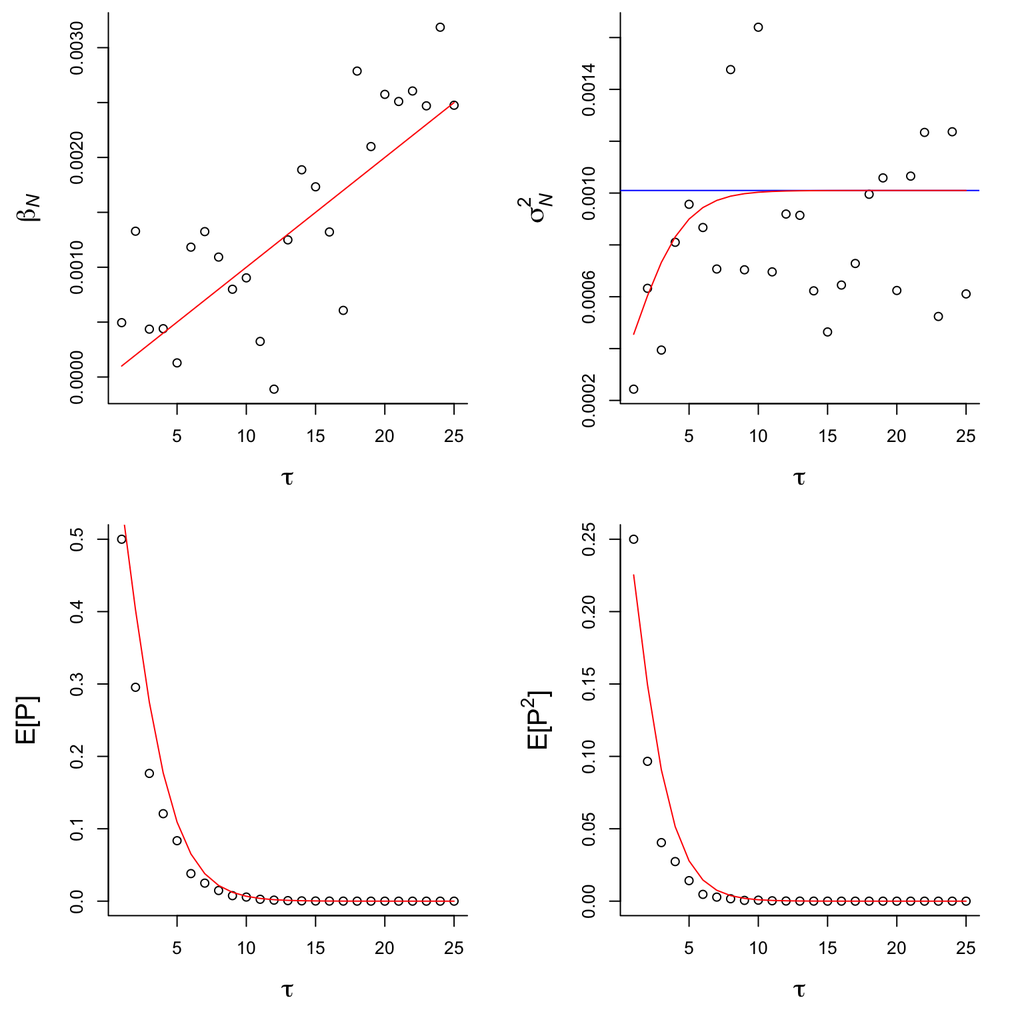

Figure 6.1: Contribution of novel mutations to the mean ($\beta_{\mathscr{N}}$) and between-line variance ($\sigma^2_{\mathscr{N}}$) in fitness (top row) and the expected frequency ($E[P]$) and expected squared frequency ($E[P^2]$) of mutants (bottom row) as a function of the number of population doublings ($\tau$). Points are obtained via simulation and red lines are the theoretical predictions. The blue line is the large $\tau$ approximation for $\sigma^2_{\mathscr{N}}$.

## 6.3 Bias correction

We do not know what the true values of $\beta_M$ and $\sigma^2_M$ are, but we do have estimates for them. However, these estimates will be biased when the number of putative mutations is not equal to the number of true mutations.

Since we assume both the mean and between-line variance scale linearly with the number of mutations, we can get an approximate expression for the bias from linear-regression theory: $E[\widehat{\beta_M}] = \rho \beta_M$ and $E[\widehat{\sigma^2_M}] = \rho \sigma^2_M$ where $\rho$ is the regression of the number of true mutations ($n^{(tp)}+n^{(fn)}$) on the number of putative mutations ($n_i=(1-\delta)(n^{(tp)}_{i}+n^{(fp)}_{i})+\delta(n^{(tp)}_{j}+n^{(fp)}_{j})$):

$$\begin{equation}
\begin{array}{rl}
\rho =& \frac{COV((1-\delta)(n^{(tp)}_{i}+n^{(fp)}_{i})+\delta(n^{(tp)}_{j}+n^{(fp)}_{j}), n^{(tp)}_{i}+n^{(fn)}_{i})}{VAR((1-\delta)(n^{(tp)}_{i}+n^{(fp)}_{i})+\delta(n^{(tp)}_{j}+n^{(fp)}_{j}))}\\
=& \frac{(1-p_M)VAR(n^{(tp)})}{VAR(n^{(tp)}+n^{(fp)})}\\
\end{array}
\end{equation}$$

Again, assuming the number of true-positives and false-positives are independent and Poisson distributed this becomes:

$$\begin{equation}
\begin{array}{rl}
\rho =& \frac{(1-p_M)E[n^{(tp)}]}{E[n^{(tp)}]+E[n^{(fp)}]}\\
\end{array}
\end{equation}$$

We do not know the expected number of false-positives per line, but we expect it to be very low. Assuming it is the same as the expected false-negative rate we get $\rho$=0.953: the attenuation due to false-positives and mix-ups is modest. Note that the number of false-negatives does not appear in this expression because they introduce Berkson errors rather than classical errors and therefore do not result in slope attenuation (Berkson 1950).

The expected between-line variance for MA lines, conditional on the number of putative mutations ($n$) is

$$\begin{equation}
\begin{array}{rl}
V_{MA} =&\rho n\sigma^2_M+\mu_g(\beta_M^2+\sigma^2_M)+(E[n^{(fn)}]+p_mE[n^{(tp)}])(\beta_M^2+\sigma^2_M)+p_m(1-p_m)E[n^{(tp)}]^2\beta_M^2+\sigma^2_E\\
V_{MA} =&\left(\rho n+E[n^{(fn)}]+p_mE[n^{(tp)}]+\mu_g\right)\sigma^2_M+\left(\mu_g+E[n^{(fn)}]+p_mE[n^{(tp)}]+p_m(1-p_m)E[n^{(tp)}]^2\right)\beta_M^2+\sigma^2_E\\
\end{array}
\end{equation}$$

The expected difference between the ancestor’s fitness and the mean fitness of the MA lines is

$$\begin{equation}
\begin{array}{rl}
E[r_A-r_{MA}]=&\beta_A-\beta_M(\rho n+E[n^{(fn)}]+p_mE[n^{(tp)}]+\mu_g\Delta\tau)\\
\end{array}
\end{equation}$$

`m_correction` is a function that can fit this model using maximum-likelihood. A model formula is passed together with the data frame, the error rate parameters (`Etp`, `Efp`, `Efn` and `p_m`), $\mu_g$ (`mu_g`) and $\Delta\tau$ (`dtau`). The model formula should contain the terms `n` and `(sqrt(n)-1|line)` where `n` is the number of putative mutations. The covariate $n$ is replaced by $\rho n+E[n^{(fn)}]+p_mE[n^{(tp)}]+\mu_g\Delta\tau$ in the fixed formula (with coefficient $\beta_M$) and by $\rho n+E[n^{(fn)}]+p_mE[n^{(tp)}]+\mu_g$ in the random slope formula. An additional between-line variance component is included with the variance $\left(\mu_g+E[n^{(fn)}]+p_mE[n^{(tp)}]+p_m(1-p_m)E[n^{(tp)}]^2\right)\beta_M^2$. If a column `anc` (indicating whether a line is ancestral (1) or not (0)) is present in the data frame, the covariates and additional variance component are set to zero for observations on ancestral lines, under the assumption they are free of any error. Note that in this instance it is the contribution of novel mutations to the *difference* between the ancestor and MA lines that is corrected through the term `dtau` (i.e. $\beta_A$ is corrected, but $\beta_0$ remains biased by novel mutations). If a column `anc` is not present a value for `dtau` can be passed that is equal to the number of generations experienced by MA lines and the effect of novel mutations on $\beta_0$ will be corrected for ($\beta_A$ is not defined in this case). Conditional on $\beta_M$ the model can be fitted as a standard linear-mixed model and the likelihood extracted. We fit the mixed model using glmmTMB since it allows variances to be fixed, unlike lmer. `optim` is used to select the $\beta_M$ that maximises the conditional likelihood.

```r
library(glmmTMB)

m_correction<-function(formula, data, dtau=NULL, mu_g=NULL, Etp=NULL, Efp=NULL, Efn=NULL, p_m=NULL){

  m1<-glmmTMB(formula,  data=data)

  if(!"n"%in%colnames(data)){
    stop("Expecting a column 'n' in data")
  }
  if(!"line"%in%colnames(data)){
    stop("Expecting a column 'line' in data")
  }
  if("anc"%in%colnames(data)){
    if(any(sort(unique(data$anc))!=c(0,1))){stop("if the column anc is present it should have either zero (an MA line) or 1 (an ancestor)")}
    anc<-TRUE
    if(!"noanc"%in%colnames(data)){
       data[,"noanc"]<-1-data[,"anc"]
    }
  }else{
    anc<-FALSE
  }

  ff<-gsub(" ", "", formula)

  if(any(grepl("new_n|new_n2|line2", ff[3]))){
    stop("Sorry new_n, new_n2 and line2 are reserved, please rename these variables")
  }

  if(!grepl("(^|\\+)n($|\\+)", ff[3])){
     stop("expecting n to be fitted as a covariate in model formula")
  }

  if(!grepl("\\(sqrt\\(n\\)-1\\|line\\)", ff[3])){
     stop("expecting (sqrt(n)-1|line) to be fitted in model formula")
  }

  ff[3]<-gsub("^n\\+", "new_n+", ff[3])
  ff[3]<-gsub("\\+n\\+", "+new_n+", ff[3])
  ff[3]<-gsub("\\+n$", "+new_n", ff[3])
  ff[3]<-gsub("\\(sqrt\\(n\\)-1\\|line\\)", "(sqrt(new_n2)-1|line)", ff[3])
  # ensures equivalent fixed effects stay in the same position and variances are offset by one

  updated_formula<-as.formula(paste(ff[c(2,1,3)], collapse=""))

  if(anc){
    updated_formula<-update(updated_formula, .~(noanc-1|line2)+.)
  }else{
    updated_formula<-update(updated_formula, .~(1|line2)+.)
  }
  # add line2 as the first set of random effects

  rho<-(1-p_m)*Etp/(Etp+Efp)

  data[,"new_n"]<-rho*data$n+Efn+p_m*Etp+mu_g*dtau
  data[,"new_n2"]<-rho*data$n+mu_g+Efn+p_m*Etp

  data[,"line2"]<-data$line

  if(anc){
     data[which(data$anc==1),"new_n"]<-0
     data[which(data$anc==1),"new_n2"]<-0
  }

  nLL<-function(par, data, m1, formula, mu_g, Etp, Efn, p_m, nLLonly=TRUE){

     bMbias<-(mu_g+Efn+p_m*Etp+p_m*(1-p_m)*(Etp^2))*par^2

     n_pos<-which(names(fixef(m1)$cond)=="n")

     beta_start<-fixef(m1)$cond
     beta_start[n_pos]<-par

     beta_map<-seq_along(beta_start)
     beta_map[n_pos]<-NA
     beta_map<-as.factor(beta_map)

     theta_start<-c(log(sqrt(bMbias)), log(sqrt(unlist(VarCorr(m1)$cond))))

     theta_map<-seq_along(theta_start)
     theta_map[1]<-NA
     theta_map<-as.factor(theta_map)

     m_tmp<-glmmTMB(formula,  data=data, REML=FALSE, start = list(beta=beta_start, theta = theta_start), map = list(beta=beta_map, theta = theta_map))

     if(nLLonly){
        return(m_tmp$fit$objective)
     }else{
        return(m_tmp)
     }
  }

  bM<-optim(par=fixef(m1)$cond["n"], nLL, data=data, m1=m1, formula=updated_formula, mu_g=mu_g, Etp=Etp, Efn=Efn, p_m=p_m, hessian=FALSE)$par

  return(nLL(par=bM, data=data, m1=m1, formula=updated_formula, mu_g=mu_g, Etp=Etp, Efn=Efn, p_m=p_m, nLLonly=FALSE))
}
```

We can test how well this model recovers true values using simulation. We simulate data according to our experimental design, but substantially increase the error rates, mix-up rates and $\mu_g$: these values are so small in reality that the expected bias would be small and hard to detect (see below). We also use large values of $\beta_m$, $\sigma^2_M$ and $\sigma^2_E$ for the same reason:

```r
mu_g_sim<-0.01
dtau_sim<-20

b_0_sim<-0
b_M_sim<-0.5
s2_M_sim<-1
s2_E_sim<-0.5
s2_e_sim<-0.01

p_m_sim<-0.2
Etp_sim<-1
Efn_sim<-0.2
Efp_sim<-0.1
```

```r
nlines<-192
nrep<-14
nsim<-500

estsim<-matrix(NA, nsim, 8)

colnames(estsim)<-c("b_0.1", "b_M.1", "s2_E.1", "s2_M.1", "b_0.2", "b_M.2", "s2_E.2", "s2_M.2")

for(i in 1:nsim){

  delta<-rbinom(nlines, size=1, prob=p_m_sim)

  nfn<-rpois(nlines, Efn_sim)
  ntp<-rpois(nlines, Etp_sim)
  nfp<-rpois(nlines, Efp_sim)

  nj<-rpois(nlines, Etp_sim+Efp_sim)    # Observed mutations given a mix-up

  n_true<-ntp+nfn                       # True mutations
  n<-(1-delta)*(ntp+nfp)+delta*nj       # Observed mutations

  line_mean<-unlist(lapply(sapply(n_true, rnorm, mean=b_M_sim, sd=sqrt(s2_M_sim)), sum))

  # effect of true mutations
  line_mean<-line_mean+rnorm(nlines, b_0_sim, sqrt(s2_E_sim))
  # effect of line environment

  for(j in 1:nlines){
    line_mean[j]<-line_mean[j]+mean(sim_new(dtau_sim, mu_g_sim, b_M_sim, s2_M_sim))
    # add the contribution of novel mutations
  }

  y<-sapply(line_mean, function(x){rnorm(nrep, x, sqrt(s2_e_sim))})
  # generate nrep replicates per line and add noise

  dat<-data.frame(y=c(y), line=as.factor(rep(1:nlines, each=nrep)), n=rep(n, each=nrep))

  m1.sim<-glmmTMB(y~n+(1|line)+(sqrt(n)-1|line), data=dat)

  m2.sim<-m_correction(y~n+(1|line)+(sqrt(n)-1|line), data=dat, dtau=dtau_sim, mu_g=mu_g_sim, Etp=Etp_sim, Efp=Efp_sim, Efn=Efn_sim, p_m=p_m_sim)

  estsim[i,]<-c(fixef(m1.sim)$cond, unlist(VarCorr(m1.sim)$cond), fixef(m2.sim)$cond, unlist(VarCorr(m2.sim)$cond)[c("line", "line.1")])

  print(i)

}
```

We can start by plotting the naive estimates, with true values in blue and their expected (biased) values in red and observed means in black:

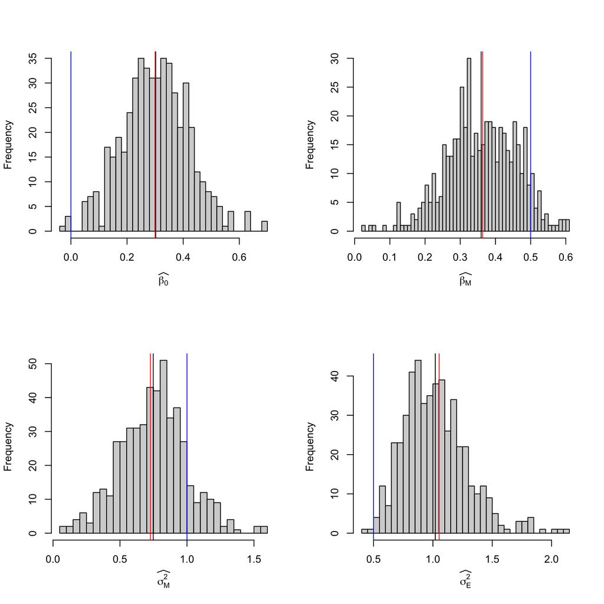

Figure 6.2: Naive estimates of fixed effects (top row) and variance components (bottom row) from simulations in which novel mutations, mutation calling errors and mix-ups exist at high frequency but are not corrected for. True values of the model parameters are in blue and the mean of the naive estimates are in black. Red is the expected (biased) estimate derived theoretically.

There are substantial biases in the estimates and these are well predicted by our theoretical expectations. We can also look at the estimates from the model that tries to accommodate mutation calling errors, mix-ups and novel mutations. Again, we plot the true values in blue, the expected `naive’ biased estimator in red and the mean of the estimates in black.

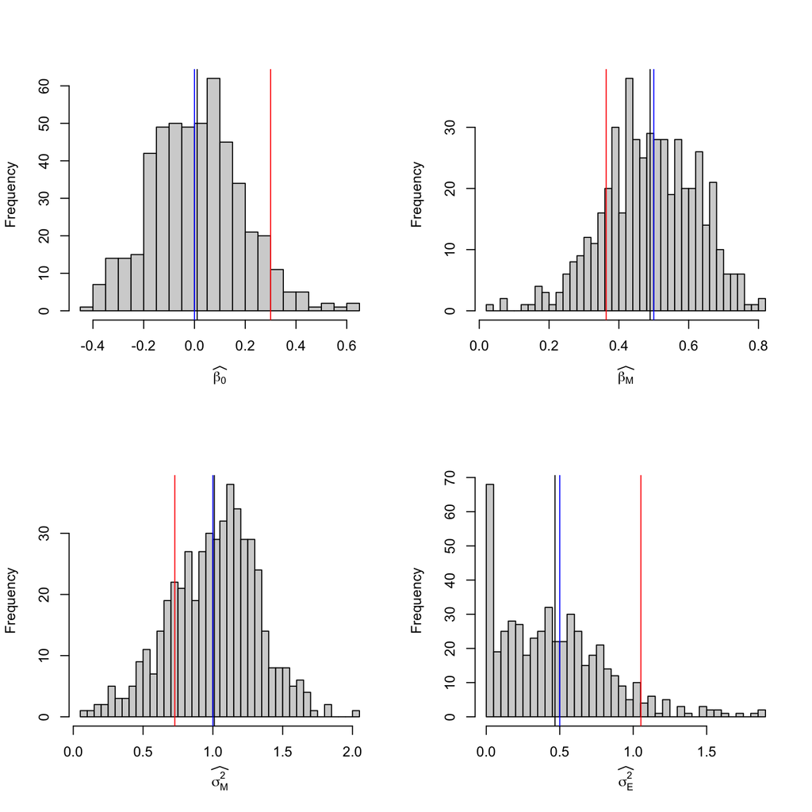

Figure 6.3: Estimates of fixed effects (top row) and variance components (bottom row) from simulations in which novel mutations, mutation calling errors and mix-ups exist at high frequency but are corrected for using `m_correction`. True values of the model parameters are in blue and the mean of the corrected estimates are in black. Red is the expected estimate had the novel mutations, mutation calling errors and mix-ups not been corrected for (derived theoretically) - see Figure 6.2

We can apply these models to our own data, but using our empirically assessed error rate parameters. First with $\Delta\tau=$ 28:

```r
m1_correct<-m_correction(r~n + anc + person + inner + (noanc-1|line) + (sqrt(n)-1|line) + (1|plate) + (1|plate:column) + (1|plate:row), data=df, dtau=dtau, mu_g=mu_g, Etp=Etp, Efp=Efp, Efn=Efn, p_m=p_m)

summary(m1_correct)
```

```
##  Family: gaussian  ( identity )
## Formula:
## r ~ (noanc - 1 | line2) + new_n + anc + person + inner + (noanc -
##     1 | line) + (sqrt(new_n2) - 1 | line) + (1 | plate) + (1 |
##     plate:column) + (1 | plate:row)
## Data: data
##
##       AIC       BIC    logLik -2*log(L)  df.resid
##   -9461.9   -9403.3    4741.0   -9481.9      2589
##
## Random effects:
##
## Conditional model:
##  Groups       Name         Variance  Std.Dev.
##  line2        noanc        7.260e-09 8.520e-05
##  line         noanc        3.182e-04 1.784e-02
##  line.1       sqrt(new_n2) 3.773e-11 6.142e-06
##  plate        (Intercept)  1.004e-03 3.169e-02
##  plate.column (Intercept)  4.924e-05 7.017e-03
##  plate.row    (Intercept)  1.809e-04 1.345e-02
##  Residual                  1.171e-03 3.422e-02
## Number of obs: 2599, groups:
## line2, 188; line, 188; plate, 28; plate:column, 336; plate:row, 224
##
## Dispersion estimate for gaussian family (sigma^2): 0.00117
##
## Conditional model:
##               Estimate Std. Error z value Pr(>|z|)
## (Intercept)  1.0878752  0.0088176  123.38  < 2e-16 ***
## new_n       -0.0002707         NA      NA       NA
## anc          0.0273389  0.0051315    5.33 9.95e-08 ***
## personJDH    0.0068579  0.0122167    0.56  0.57455
## inner       -0.0057742  0.0019123   -3.02  0.00253 **
## ---
## Signif. codes:  0 '***' 0.001 '**' 0.01 '*' 0.05 '.' 0.1 ' ' 1
```

Since the original estimates of $\beta_M$ and $\sigma^2_M$ were small and non-significant we did not expect large changes in the estimate of $\sigma^2_E$, and indeed it was 0.9921 times its original value. However, we do expect mutation calling errors, mix-ups and novel mutations to make it harder to detect non-genetic between line variance and indeed the p-value is less extreme, although $\sigma^2_E$ still remains significantly different from zero.

```r
m7_correct<-m_correction(r~n + anc + person + inner + (sqrt(n)-1|line) + (1|plate) + (1|plate:column) + (1|plate:row), data=df, dtau=dtau, mu_g=mu_g, Etp=Etp, Efp=Efp, Efn=Efn, p_m=p_m)

anova(m1_correct, m7_correct)
```

```
## Data: data
## Models:
## m7_correct: r ~ (noanc - 1 | line2) + new_n + anc + person + inner + (sqrt(new_n2) - , zi=~0, disp=~1
## m7_correct:     1 | line) + (1 | plate) + (1 | plate:column) + (1 | plate:row), zi=~0, disp=~1
## m1_correct: r ~ (noanc - 1 | line2) + new_n + anc + person + inner + (noanc - , zi=~0, disp=~1
## m1_correct:     1 | line) + (sqrt(new_n2) - 1 | line) + (1 | plate) + (1 | , zi=~0, disp=~1
## m1_correct:     plate:column) + (1 | plate:row), zi=~0, disp=~1
##            Df     AIC     BIC logLik deviance  Chisq Chi Df Pr(>Chisq)
## m7_correct  9 -9423.7 -9371.0 4720.9  -9441.7
## m1_correct 10 -9461.9 -9403.3 4741.0  -9481.9 40.216      1  2.273e-10 ***
## ---
## Signif. codes:  0 '***' 0.001 '**' 0.01 '*' 0.05 '.' 0.1 ' ' 1
```

Assuming $\Delta\tau=$ -28 makes little difference

```r
m1b_correct<-m_correction(r~n + anc + person + inner + (noanc-1|line) + (sqrt(n)-1|line) + (1|plate) + (1|plate:column) + (1|plate:row), data=df, dtau=-dtau, mu_g=mu_g, Etp=Etp, Efp=Efp, Efn=Efn, p_m=p_m)
m7b_correct<-m_correction(r~n + anc + person + inner + (sqrt(n)-1|line) + (1|plate) + (1|plate:column) + (1|plate:row), data=df, dtau=-dtau, mu_g=mu_g, Etp=Etp, Efp=Efp, Efn=Efn, p_m=p_m)

summary(m1b_correct)
```

```
##  Family: gaussian  ( identity )
## Formula:
## r ~ (noanc - 1 | line2) + new_n + anc + person + inner + (noanc -
##     1 | line) + (sqrt(new_n2) - 1 | line) + (1 | plate) + (1 |
##     plate:column) + (1 | plate:row)
## Data: data
##
##       AIC       BIC    logLik -2*log(L)  df.resid
##   -9461.9   -9403.3    4741.0   -9481.9      2589
##
## Random effects:
##
## Conditional model:
##  Groups       Name         Variance  Std.Dev.
##  line2        noanc        7.260e-09 8.520e-05
##  line         noanc        3.182e-04 1.784e-02
##  line.1       sqrt(new_n2) 3.773e-11 6.142e-06
##  plate        (Intercept)  1.004e-03 3.169e-02
##  plate.column (Intercept)  4.924e-05 7.017e-03
##  plate.row    (Intercept)  1.809e-04 1.345e-02
##  Residual                  1.171e-03 3.422e-02
## Number of obs: 2599, groups:
## line2, 188; line, 188; plate, 28; plate:column, 336; plate:row, 224
##
## Dispersion estimate for gaussian family (sigma^2): 0.00117
##
## Conditional model:
##               Estimate Std. Error z value Pr(>|z|)
## (Intercept)  1.0878586  0.0088177  123.37  < 2e-16 ***
## new_n       -0.0002707         NA      NA       NA
## anc          0.0273549  0.0051315    5.33 9.78e-08 ***
## personJDH    0.0068589  0.0122168    0.56  0.57450
## inner       -0.0057735  0.0019123   -3.02  0.00253 **
## ---
## Signif. codes:  0 '***' 0.001 '**' 0.01 '*' 0.05 '.' 0.1 ' ' 1
```

```r
anova(m1b_correct, m7b_correct)
```

```
## Data: data
## Models:
## m7b_correct: r ~ (noanc - 1 | line2) + new_n + anc + person + inner + (sqrt(new_n2) - , zi=~0, disp=~1
## m7b_correct:     1 | line) + (1 | plate) + (1 | plate:column) + (1 | plate:row), zi=~0, disp=~1
## m1b_correct: r ~ (noanc - 1 | line2) + new_n + anc + person + inner + (noanc - , zi=~0, disp=~1
## m1b_correct:     1 | line) + (sqrt(new_n2) - 1 | line) + (1 | plate) + (1 | , zi=~0, disp=~1
## m1b_correct:     plate:column) + (1 | plate:row), zi=~0, disp=~1
##             Df     AIC     BIC logLik deviance  Chisq Chi Df Pr(>Chisq)
## m7b_correct  9 -9423.7 -9371.0 4720.9  -9441.7
## m1b_correct 10 -9461.9 -9403.3 4741.0  -9481.9 40.216      1  2.273e-10 ***
## ---
## Signif. codes:  0 '***' 0.001 '**' 0.01 '*' 0.05 '.' 0.1 ' ' 1
```

$\sigma^2_E$ remains significant even if we assume the error rates and $\Delta\tau$ are an order of magnitude larger than their assumed values:

```r
m1c_correct<-m_correction(r~n + anc + person + inner + (noanc-1|line) + (sqrt(n)-1|line) + (1|plate) + (1|plate:column) + (1|plate:row), data=df, dtau=dtau*10, mu_g=mu_g, Etp=203/192, Efp=Efp*10, Efn=Efn*10, p_m=p_m*10)

m7c_correct<-m_correction(r~n + anc + person + inner + (sqrt(n)-1|line) + (1|plate) + (1|plate:column) + (1|plate:row), data=df, dtau=dtau*10, mu_g=mu_g, Etp=203/192, Efp=Efp*10, Efn=Efn*10, p_m=p_m*10)

anova(m1c_correct, m7c_correct)
```

```
## Data: data
## Models:
## m7c_correct: r ~ (noanc - 1 | line2) + new_n + anc + person + inner + (sqrt(new_n2) - , zi=~0, disp=~1
## m7c_correct:     1 | line) + (1 | plate) + (1 | plate:column) + (1 | plate:row), zi=~0, disp=~1
## m1c_correct: r ~ (noanc - 1 | line2) + new_n + anc + person + inner + (noanc - , zi=~0, disp=~1
## m1c_correct:     1 | line) + (sqrt(new_n2) - 1 | line) + (1 | plate) + (1 | , zi=~0, disp=~1
## m1c_correct:     plate:column) + (1 | plate:row), zi=~0, disp=~1
##             Df     AIC     BIC logLik deviance  Chisq Chi Df Pr(>Chisq)
## m7c_correct  9 -9458.0 -9405.3   4738  -9476.0
## m1c_correct 10 -9461.9 -9403.3   4741  -9481.9 5.9185      1    0.01498 *
## ---
## Signif. codes:  0 '***' 0.001 '**' 0.01 '*' 0.05 '.' 0.1 ' ' 1
```

# 7 Antedependence Models of Environmental Effects

In the discussion we touched on a number of topics that implicitly assumed an antedependence model for the environmental contribution to the between-line variance. Here, we give a short non-technical summary and a more theoretical development of these ideas in order to fix some concepts more precisely.

In what follows we envisage a set-up where a number of MA lines have been propagated for a number of generations from a common ancestor. From each line, a number of sub-lines are then generated and propagated until their growth rates are measured. These measurements constitute the replicates for each line. We envisage a model for the non-mutational (henceforth environmental) effects whereby new environmental perturbations are constantly being introduced in a (sub)line but their effects decay over time. In what follows, two key concepts need to be understood: a) environmental perturbations that arise in a line before the sub-lines are generated will generate between-line variance if they have not decayed by the time measurements are made and b) in the early stages of MA the between-line environmental variance will be small, but as new environmental perturbations are added each generation the environmental variance will increase to some equilibrium value where the input of new environmental perturbations is balanced by the decay of historical perturbations. Concept a) allows us to imagine an experimental design that minimises the environmental between-line variance: if sub-lines can be propagated for as many generations as it takes for their shared environmental effects to decay, any `memory’ of historical environmental perturbations will be lost and there will be no environmental between-line variance, only within-line. In cases where these requirements cannot be met, Concept b) allows us to imagine an alternative experimental design. If the MA lines have been propagated for a sufficiently long period then the environmental variance will have come to an equilibrium and the environmental between-line variance will be constant over subsequent generations. However, the mutational variance will continue to increase each generation (since mutations do not decay) such that *changes* in the between-line variance over the course of an MA experiment can give an estimate of the mutational variance.

To understand these intuitive ideas more formally, we use an antedependence model for the growth rate measurement on replicate $j$ for line $i$ taken in generation $t$:

$$\begin{equation}
r_{ij, t} = G_{i,t-1} + \psi E_{i,t-1}+\Delta G_{i,t}+\Delta E_{i,t}+e_{ij,t}
\end{equation}$$

where $G_{i,t-1}$ is the genetic value in the previous generation and $\Delta G_{i,t}$ the increment in the current generation due to new mutations. $E_{i,t-1}$ is the environmental effect in the previous generation that is passed on with fidelity $\psi$ and $\Delta E_{i,t}$ is the increment in this inherited environmental effect. $e_{ij,t}$ is the environmental effect specific to that measurement and includes measurement error. We can rewrite the equation as

$$\begin{equation}
r_{ij, t} = \sum_{k=0}^{t} \Delta G_{i,k} + \sum_{k=0}^{t} \psi^{t-k}\Delta E_{i,k}+e_{ij,t}
\end{equation}$$

The between-line covariance between a set of replicates who had a common ancestor at time $t$ and were measured at time $t+m$ and $t+n$ (i.e the two sub-lines were propagated for $m$ and $n$ generations respectively) is:

$$\begin{equation}
\begin{array}{rl}
%Cov(r_{ij, t+m},r_{ij, t+n}) =& Cov\left(\sum_{k=0}^{t+m} \Delta G_{i,k} + \sum_{k=0}^{t+m} \psi^{t+m-k}\Delta E_{i,k}+e_{ij,t}, \sum_{k=0}^{t+n} \Delta G_{i,k} + \sum_{k=0}^{t+n} \psi^{t+n-k}\Delta E_{i,k}+e_{ij,t+n}\right)\\
%Cov(r_{ij, t+m},r_{ij, t+n}) =& Cov\left(\sum_{k=0}^{t+m} \Delta G_{i,k} + \sum_{k=0}^{t+m} \psi^{t+m-k}\Delta E_{i,k}, \sum_{k=0}^{t+n} \Delta G_{i,k} + \sum_{k=0}^{t+n} \psi^{t+n-k}\Delta E_{i,k}\right)\\
%Cov(r_{ij, t+m},r_{ij, t+n}) =& Cov\left(\sum_{k=0}^{t} \Delta G_{i,k} + \sum_{k=0}^{t} \psi^{t+m-k}\Delta E_{i,k}, \sum_{k=0}^{t} \Delta G_{i,k} + \sum_{k=0}^{t} \psi^{t+n-k}\Delta E_{i,k}\right)\\
%Cov(r_{ij, t},r_{ij, t+n}) =& t\sigma^2_{\Delta G}+ Cov\left(\sum_{k=0}^{t} \psi^{t+m-k}\Delta E_{i,k}, \sum_{k=0}^{t} \psi^{t+n-k}\Delta E_{i,k}\right)\\
%Cov(r_{ij, t+m},r_{ij, t+n}) =& t\sigma^2_{\Delta G}+ \sum_{k=0}^{t} Cov\left(\psi^{t+m-k}\Delta E_{i,k}, \psi^{t+n-k}\Delta E_{i,k}\right)\\
%Cov(r_{ij, t+m},r_{ij, t+n}) =& t\sigma^2_{\Delta G}+ \sum_{k=0}^{t} \psi^{t+m-k}\psi^{t+n-k}Var(\Delta E_{i,k})\\
%Cov(r_{ij, t+m},r_{ij, t+n}) =& t\sigma^2_{\Delta G}+ \sum_{k=0}^{t} \psi^{2(t-k)}\psi^{n+m}Var(\Delta E_{i,k})\\
COV(r_{ij, t+m},r_{ij, t+n}) =& t\sigma^2_{\Delta G} + \psi^{n+m}\sigma^2_{\Delta E}\sum_{k=1}^{t}\psi^{2(t-k)}\\
\end{array}
\end{equation}$$

assuming that the new mutational and inherited environmental increments are identically and independently distributed, both across lines and in time, with variances $\sigma^2_{\Delta G}$ and $\sigma^2_{\Delta E}$ respectively. We use the notation $\sigma^2_{\Delta E}$ for the variance in the *per generation* environmental effects to distinguish it from $\sigma^2_{E}$, the total accumulated environmental variance between lines at the time of measurement. $G_{i,0}$ and $E_{i,0}$ are constant as all lines are assumed to have been derived from the same ancestor at time zero, although this could be relaxed. $t\sigma^2_{\Delta G}=t\mu_g\sigma^2_M$ is the accumulated mutational variance which grows linearly in time because mutational effects are passed on with perfect fidelity (assuming no directional epistasis or selection). $\sigma^2_{\Delta E}\sum_{k=1}^{t}\psi^{2(t-k)}$ is the amount of environmental variance that has accumulated by time $t$ and this increases quickly initially, but asymptotes to $\sigma^2_{\Delta E}/(1-\psi^2)$ as $t$ becomes large. However, the environmental effect initially shared by a set of sub-lines will decay independently in each sub-line as they are propagated, thus reducing their contribution to the between-line covariance by an amount $\psi^{m+n}$. In Figure 7.1 we give a graphical representation of these equations (see caption for details).

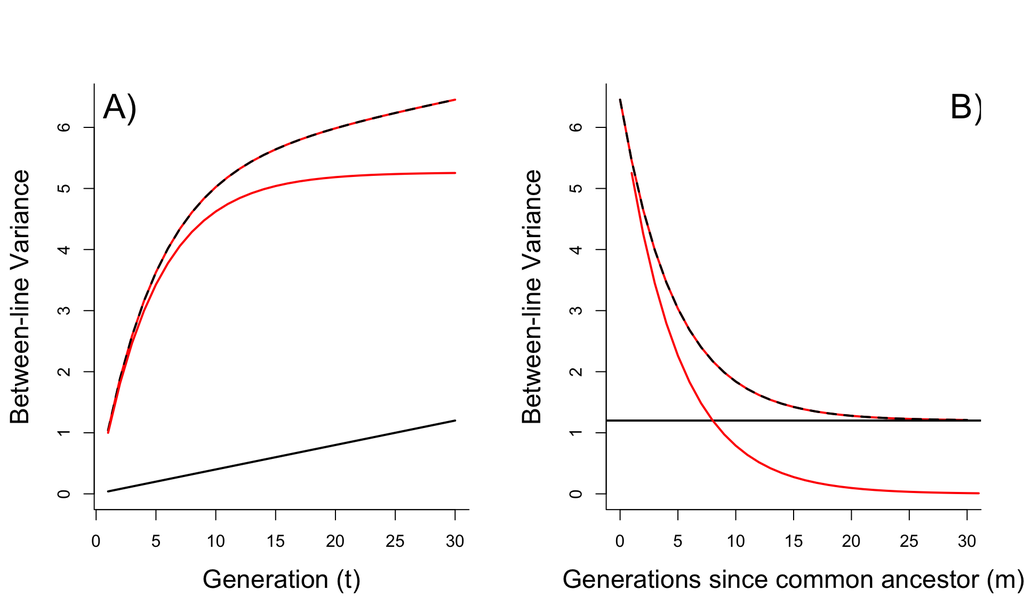

Figure 7.1: Between-line variances as a function of A) how many generations ($t$) of MA have been conducted assuming no generations separate replicates from their common ancestor ($m=n=0$) and B) how many generations separate replicates from their common ancestor ($m=n$) given 30 generations of MA ($t=30$). The dashed black and red line is the total between-line variance which can be decomposed into contributions from the mutational variance (black) and inherited environmental variance (red). The parameters $\sigma^2_{\Delta E}=1$, $\sigma^2_{\Delta G}=0.04$, $\psi=0.9$ were used. At $t=30$ the inherited environmental variance ($\sigma^2_E$) is close to its stationary value $\sigma^2_{\Delta E}/(1-\psi^2)=5.26$ and the increase in the total between line variances is approximately linear due to the accumulation of new mutations.

```r
# Note the resulting between-line (co)variance matrix assumes
# m=n=0 along the diagonal and m=0 for the off-diagonals

sd_DE<-1    # standard deviation of new (pre generation) environmental effects
sd_DG<-0.2  # standard deviation of new (pre generation) mutational effects
psi<-0.9   # transmissibility of environmental effects
n_t<-30    # number of generations
n_l<-10000 # number of lines
start_staionarity<-FALSE  # should the process be initiated assuming stationarity


if(start_staionarity){
  e<-rnorm(n_l, 0, sd_DE/sqrt(1-psi^2))
}else{
  e<-rep(0, n_l)              # ancestral environmental effects (same for all lines)
}

g<-rep(0, n_l)              # ancestral genetic effects (same for all lines)

y<-matrix(NA, n_t, n_l)     # matrix of line means (columns) in each generation (row)

for(i in 1:n_t){
e<-rnorm(n_l, e*psi, sd_DE)  # inherit part of e from previous generation and add some new e
g<-rnorm(n_l, g*1.0, sd_DG)  # inherit all of g from previous generation and add some new g

y[i,]<-e+g                 # lines means
}

V<-cov(t(y))  # n_t by n_t (co)variance matrix over lines

par(mfrow=c(1,2))
t<-1:n_t
k<-n_t:1
pred<-t*sd_DG^2+cumsum(psi^(2*(n_t-k)))*sd_DE^2
par(mar=c(5, 4.5, 4, 2) + 0.1)
plot(pred, xlab="Generation (t)", ylab="Between-line Variance", ylim=c(0,max(pred)), col="red", type="l", bty="l", cex.lab=1.5, lwd=2)
text(2, 6.3, "A)", cex=2)
lines(pred, lty=2, lwd=2)
lines(t*sd_DG^2, lwd=2)
lines(cumsum(psi^(2*(n_t-k)))*sd_DE^2, lwd=2, col="red")

t<-1:n_t
k<-n_t:1
VE<-sum(psi^(2*(n_t-k)))*sd_DE^2

n<-0:30
pred<-max(t)*sd_DG^2+(psi^(2*n))*VE
par(mar=c(5, 4.5, 4, 2) + 0.1)
plot(pred~n, xlab="Generations since common ancestor (m)", ylab="Between-line Variance", ylim=c(0,max(pred)), col="red", type="l", bty="l", cex.lab=1.5, lwd=2)
text(30, 6.3, "B)", cex=2)
lines(pred~n, lty=2, lwd=2)
abline(h=max(t)*sd_DG^2, lwd=2)
lines((psi^(2*n))*VE, lwd=2, col="red")
```

The notation is sufficiently general to cover most MA procedures and measurement protocols. In most large multicellular organisms $m$ will often be one. For example, an MA line may be propagated by brother-sister mating and at generation $t+1$ a brother and sister are retained as the founders of the next generation and their remaining siblings (the sub-lines) are measured. In most microbial work $m$ may be quite large as a sub-line is grown up and the fitness assays are inherently multigenerational. For example, in our experiment, each sub-line was grown for 16 hours from frozen stock followed by 4 hours on a 96-well plate within which fitness was measured as the growth rate over a twenty-minute period. $m$ is therefore likely to be tens of generations. At the other extreme, it may be possible to obtain measurements on parents and offspring. Then, $m=0$ (for the parent) and $n=1$ (for the offspring).

If $t$ is sufficiently large, the contribution of the inherited environmental variance to the between-line variance becomes constant, and then the slope of the regression of the between-line variance on generation is a good estimator of $\sigma^2_{\Delta G} = \mu_g\sigma^2_M$. However, if the inherited environmental effects have yet to reach stationarity ($t<15$ in Figure 7.1) then the slope would overestimate $\sigma^2_{\Delta G}$ due to the environmental contribution still increasing over time. If $m$ is sufficiently large then the shared environmental effects will have dissipated ($m>20$ in Figure 7.1) and no longer contribute to the between-line variance, which is then a good estimator of $t\sigma^2_{\Delta G}=t\mu_g\sigma^2_M$.

If fitness measurements were available at a range of $t$ and/or $m$, yet it was found that neither $t$ nor $m$ were sufficiently large for the environmental between-line variance to asymptote (to zero if $m$ is large), the data could still be used to get estimates of $\sigma^2_{\Delta G}$ by fitting an antedependence model and co-estimating $\sigma^2_{\Delta E}$ and $\psi$, in addition to $\sigma^2_{\Delta G}$. Such a model has been developed and fitted to data collected on *Drosophila melanogaster* MA lines (Mackay, Lyman, and Hill 1995). However, it should be emphasised that in that paper the non-linear change in the between-line variance is attributed to selection operating on new mutations which essentially causes mutational effects to be inherited without perfect fidelity, as measured through $\psi$. In addition, the authors also note that excess residual heterozygosity in the ancestor (relative to the asymptotic within-line genetic variance expected under MA) and diminishing returns epistasis would also cause the between-line variance to increase faster in early generations, and so interpreting $\psi$ as a measure of selection requires some care. The issue of excess residual heterozygosity, at least, can be dealt with by discarding data from the first $6N_e$ generations of MA, since beyond this the within-line genetic variance will have stabilised at its equilibrium value (where $N_e$ is the effective population size of an MA line).

For completeness, the within-line variance is

$$\begin{equation}
\begin{array}{rl}
%Var(r_{ij, t+m}) =& Var\left(\sum_{k=1}^{m} \Delta G_{i,t+k} + \sum_{k=1}^{m} \psi^{m-k}\Delta E_{i,t+k}+e_{ij,t+m}\right)\\
%Var(r_{ij, t+m})=&m\sigma^2_{\Delta G}+Var\left(\sum_{k=1}^{m} \psi^{m-k}\Delta E_{i,t+k}\right)+\sigma^2_e\\
VAR(r_{ij, t+m})=&m\sigma^2_{\Delta G}+\sigma^2_{\Delta E}\sum_{k=1}^{m} \psi^{2(m-k)}+\sigma^2_e\\
\end{array}
\end{equation}$$

where $m\sigma^2_{\Delta G}$ is the accumulated mutational variance, $\sigma^2_E=\sigma^2_{\Delta E}\sum_{k=1}^{m} \psi^{2(m-k)}$ is the accumulated environmental variance and $\sigma^2_e$ is the variance in non-inherited environmental effects. Note that if the organism was sexual there would be additional within-line genetic variance due to recombination and segregation.

Berkson, Joseph. 1950. “Are There Two Regressions?” *Journal of the American Statistical Association* 45 (250): 164–80.

Blackwell, David A, and Meyer A Girshick. 1979. *Theory of Games and Statistical Decisions*. Courier Corporation.

Blazanin, Michael. 2024. “gcplyr: an R package for microbial growth curve data analysis.” *BMC Bioinformatics* 25 (232).

Chernoff, Herman. 1954. “On the Distribution of the Likelihood Ratio.” *The Annals of Mathematical Statistics*, 573–78.

Chevin, Luis-Miguel. 2011. “On Measuring Selection in Experimental Evolution.” *Biology Letters* 7 (2): 210–13.

Fink, Justus Wilhelm, and Michael Manhart. 2024. “Quantifying Microbial Fitness in High-Throughput Experiments.” *bioRxiv*, 2024–08.

Lawrence, JV, and S Maier. 1977. “Correction for the Inherent Error in Optical Density Readings.” *Applied and Environmental Microbiology* 33 (2): 482–84.

Lea, Douglas E, and Charles Alfred Coulson. 1949. “The Distribution of the Numbers of Mutants in Bacterial Populations.” *Journal of Genetics* 49 (3): 264–85.

Lee, Heewook, Ellen Popodi, Haixu Tang, and Patricia L Foster. 2012. “Rate and Molecular Spectrum of Spontaneous Mutations in the Bacterium Escherichia Coli as Determined by Whole-Genome Sequencing.” *Proceedings of the National Academy of Sciences* 109 (41): E2774–83.

Mackay, TF, Richard F Lyman, and William G Hill. 1995. “Polygenic Mutation in *Drosophila Melanogaster*: Non-Linear Divergence Among Unselected Strains.” *Genetics* 139 (2): 849–59.

Sane, Mrudula, Joshua John Miranda, and Deepa Agashe. 2018. “Antagonistic Pleiotropy for Carbon Use Is Rare in New Mutations.” *Evolution* 72 (10): 2202–13.